# Report_progetto

Marta Paira

2025-11-07

# Global Setup and Data Loading

In this initial block, we load all necessary libraries, define helper functions, and load all CSV files into memory once.

## 1. Global Options

We use this setup block to define the global settings for all following R code chunks. The options `message=FALSE` and `warning=FALSE` are set to suppress loading messages and warnings, ensuring a clean and professional final report.

## 2. Library Loading

We load the required libraries.

```r
library(data.table)
library(dplyr)
library(lubridate)
library(sqldf)
library(tidyr)
library(ggplot2)
library(scales)
```

## 3. Helper function to Extract Time (in seconds)

We define the extract_time function. This function takes the complex output of system.time() and extracts only the “elapsed” time (in seconds), ready to be inserted into the performance table to compare the execution times of different approaches.

```r
extract_time <- function(time_obj) {
  return(round(time_obj["elapsed"], 6))
}
```

## 4. Data Loading

In this section, we load all necessary CSV files for the analysis. To prepare for the performance comparison, each file is first read as a data.table and then copied as a conventional R data.frame.

```r
cat("Caricamento di tutti i 13 file di dati...\n")
```

```
## Caricamento di tutti i 13 file di dati...
```

```r
dt_counts <- fread("bulk_counts_long.csv")
dt_metadata <- fread("sample_metadata.csv")
dt_labs_t5 <- fread("clinical_labs.csv")
dt_ranges_t5 <- fread("lab_reference_ranges.csv")
dt_vitals_t6 <- fread("vitals_time_series.csv")
dt_peaks_t7 <- fread("atac_peaks.bed.csv")
dt_genes_t10 <- fread("gene_annotation.bed.csv")
dt_variants_t11 <- fread("variants.csv")
dt_counts_wide_t9 <- fread("bulk_counts_wide.csv")
dt_cohortA <- fread("cohortA_samples.csv")
dt_cohortB <- fread("cohortB_samples.csv")
dt_clusters_fr <- fread("annotated_GSM3516673_normal_annotated_GSM3516672_tumor_SeuratIntegration.csv")
dt_celltypes_fr <- fread("nt_combined_clustering.output.csv")
cat("Data loaded.\n")
```

```
## Data loaded.
```

```r
df_counts <- as.data.frame(dt_counts)
df_metadata <- as.data.frame(dt_metadata)
df_labs_t5 <- as.data.frame(dt_labs_t5)
df_ranges_t5 <- as.data.frame(dt_ranges_t5)
df_vitals_t6 <- as.data.frame(dt_vitals_t6)
df_peaks_t7 <- as.data.frame(dt_peaks_t7)
df_genes_t10 <- as.data.frame(dt_genes_t10)
df_variants_t11 <- as.data.frame(dt_variants_t11)
df_counts_wide_t9 <- as.data.frame(dt_counts_wide_t9)
df_cohortA <- as.data.frame(dt_cohortA)
df_cohortB <- as.data.frame(dt_cohortB)
df_clusters_fr <- as.data.frame(dt_clusters_fr)
df_celltypes_fr <- as.data.frame(dt_celltypes_fr)
cat("data.frame copies created.\n")
```

```
## data.frame copies created.
```

## 5. Initialization of the Cumulative Performance Table

We define the main table with all possible columns for timing metrics.

```r
performance_comparison <- data.table(
  Task = character(),
  `Time_DataFrame (s)` = numeric(),
  `Time_DataTable (s)` = numeric(),
  `Time_SQL (s)` = numeric(),
  `Time_DT_NoIndex (s)` = numeric(),
  `Time_DT_Keyed/Index (s)` = numeric(),
  `Time_DT_Rolling (s)` = numeric()
)
```

## 6. Output Configuration

This section initializes the `output_dir` variable and ensures the necessary `results/` subdirectory is created. All generated files, including performance metrics and final results, will be saved here to maintain a clean project structure.

```r
output_dir <- "results"
if (!dir.exists(output_dir)) {
    dir.create(output_dir, showWarnings = FALSE)
}
```

# Task 1: Filter and Summarize

**Goal: This task performs two common analysis operations: 1) filtering and summarizing, and 2) joining and summarizing. It benchmarks the performance of three different methods (dplyr, data.table, and sqldf) for each operation.**

## Data Preparation

First, we pre-join the count and metadata tables to create unified datasets.

```r
cat("\n--- START TASK 1: PERFORMANCE COMPARISON ---\n")
```

```
##
## --- START TASK 1: PERFORMANCE COMPARISON ---
```

```r
# Pre-join data for filter task
df_unita <- df_counts %>% left_join(df_metadata, by = "sample_id")
dt_unita <- dt_counts[dt_metadata, on = "sample_id"]
```

## Task 1.1: Filter and Summarize (Mean/Median)

This sub-task filters the data to keep only treated samples and genes starting with GENE_00. It then groups by gene and calculates the mean and median counts for this specific subset.

```r
cat("\nRunning Task 1.1: Filter & Summarize...\n")
```

```
##
## Running Task 1.1: Filter & Summarize...
```

```r
# 1.1.1: Data.frame / Dplyr
time_df_1_1_result <- system.time({
  df_risultato_1_1 <- df_unita %>%
    filter(grepl("^GENE_00", gene) & condition == "treated") %>%
    group_by(gene) %>%
    summarise(media_counts = mean(count), median_counts = median(count), .groups = 'drop')
})
time_df_1_1 <- extract_time(time_df_1_1_result)
cat("DataFrame T1.1 Time:", time_df_1_1, "seconds.\n")
```

```
## DataFrame T1.1 Time: 0.008 seconds.
```

```r
# 1.1.2: Data.table
time_dt_1_1_result <- system.time({
  dt_risultato_1_1 <- dt_unita[
    grepl("^GENE_00", gene) & condition == "treated",
    list(media_counts = mean(count), median_counts = median(count)),
    by = gene
  ]
})
time_dt_1_1 <- extract_time(time_dt_1_1_result)
cat("data.table T1.1 Time:", time_dt_1_1, "seconds.\n")
```

```
## data.table T1.1 Time: 0.002 seconds.
```

```r
# 1.1.3: SQL (sqldf)
time_sql_1_1_result <- system.time({
  sql_risultato_1_1 <- sqldf::sqldf("
    SELECT T1.gene, AVG(T1.count) AS media_counts, MEDIAN(T1.count) AS median_counts
    FROM df_counts AS T1
    LEFT JOIN df_metadata AS T2 ON T1.sample_id = T2.sample_id
    WHERE T2.condition = 'treated' AND T1.gene LIKE 'GENE_00%'
    GROUP BY T1.gene
  ")
})
time_sql_1_1 <- extract_time(time_sql_1_1_result)
cat("SQL T1.1 Time:", time_sql_1_1, "seconds.\n")
```

```
## SQL T1.1 Time: 0.029 seconds.
```

```r
# Update comparison table after Task 1.1
performance_comparison <- rbindlist(
  list(
    performance_comparison,
    list(Task = "T1.1 Filter & Summarize",
         `Time_DataFrame (s)` = time_df_1_1,
         `Time_DataTable (s)` = time_dt_1_1,
         `Time_SQL (s)` = time_sql_1_1)
  ),
  use.names = TRUE, fill = TRUE
)
print(head(df_risultato_1_1, 5))
```

```
## # A tibble: 5 × 3
##   gene      media_counts median_counts
##   <chr>            <dbl>         <int>
## 1 GENE_0000         7.07             6
## 2 GENE_0001         2.53             2
## 3 GENE_0002         3.8              3
## 4 GENE_0003        20.3             19
## 5 GENE_0004         5.93             7
```

## Task 1.2: Join Metadata and Summarize by Condition

This sub-task joins the complete count data with the sample metadata. It then groups by both gene and condition to calculate the mean count for every gene in both the ‘treated’ and ‘control’ groups.

```r
cat("\nRunning Task 1.2: Join & Summarize...\n")
```

```
##
## Running Task 1.2: Join & Summarize...
```

```r
# 1.2.1: Data.frame / Dplyr
time_df_1_2_result <- system.time({
  df_risultato_1_2 <- df_counts %>%
    left_join(df_metadata, by = "sample_id") %>%
    group_by(gene, condition) %>%
    summarise(media_counts = mean(count), .groups = 'drop')
})
time_df_1_2 <- extract_time(time_df_1_2_result)
cat("DataFrame T1.2 Time:", time_df_1_2, "seconds.\n")
```

```
## DataFrame T1.2 Time: 0.005 seconds.
```

```r
# 1.2.2: Data.table
time_dt_1_2_result <- system.time({
  dt_risultato_1_2 <- dt_counts[dt_metadata, on = "sample_id"][,
                                      list(media_counts = mean(count)),
                                      by = list(gene, condition)
  ]
})
time_dt_1_2 <- extract_time(time_dt_1_2_result)
cat("data.table T1.2 Time:", time_dt_1_2, "seconds.\n")
```

```
## data.table T1.2 Time: 0.002 seconds.
```

```r
# 1.2.3: SQL (sqldf)
time_sql_1_2_result <- system.time({
  sql_risultato_1_2 <- sqldf::sqldf("
    SELECT T1.gene, T2.condition, AVG(T1.count) AS media_counts
    FROM df_counts AS T1
    LEFT JOIN df_metadata AS T2 ON T1.sample_id = T2.sample_id
    GROUP BY T1.gene, T2.condition
  ")
})
time_sql_1_2 <- extract_time(time_sql_1_2_result)
cat("SQL T1.2 Time:", time_sql_1_2, "seconds.\n")
```

```
## SQL T1.2 Time: 0.02 seconds.
```

```r
# Update comparison table after Task 1.2
performance_comparison <- rbindlist(
  list(
    performance_comparison,
    list(Task = "T1.2 Join & Summarize",
         `Time_DataFrame (s)` = time_df_1_2,
         `Time_DataTable (s)` = time_dt_1_2,
         `Time_SQL (s)` = time_sql_1_2)
  ),
  use.names = TRUE, fill = TRUE
)
print(head(df_risultato_1_2, 5))
```

```
## # A tibble: 5 × 3
##   gene      condition media_counts
##   <chr>     <chr>            <dbl>
## 1 GENE_0000 control           6.11
## 2 GENE_0000 treated           7.07
## 3 GENE_0001 control           2.67
## 4 GENE_0001 treated           2.53
## 5 GENE_0002 control           4
```

```r
# SAVE TASK 1 RESULTS
fwrite(dt_risultato_1_1, file.path(output_dir, "Task1_FilterSummarize_Results.csv"))
fwrite(dt_risultato_1_2, file.path(output_dir, "Task1_JoinSummarize_Results.csv"))
cat("\nTask 1 Analysis completed.\n")
```

```
##
## Task 1 Analysis completed.
```

# Task 2: QC-Style Derived Columns

**Goal: This task benchmarks adding new columns “in-place”, a key efficiency feature. We first add a log2_counts column and a simple binary flag (high > 100), then overwrite the high flag using a more complex gene-specific median threshold.**

## Data Preparation

```r
cat("\n--- START TASK 2: QC DERIVED COLUMNS ---\n")
```

```
##
## --- START TASK 2: QC DERIVED COLUMNS ---
```

```r
# Create clean copies of the data
dt_counts_t2 <- copy(dt_counts)
df_counts_t2 <- copy(df_counts)
df_counts_t2_baseR <- copy(df_counts)
```

## Task 2.1: Add log2_counts and Fixed Flag

This sub-task adds two new columns: a standard log2(count + 1) transformation and a simple binary flag for any count greater than 100.

```r
cat("\nRunning Task 2.1: Log2 & Fixed Flag (3-way comparison)...\n")
```

```
##
## Running Task 2.1: Log2 & Fixed Flag (3-way comparison)...
```

```r
# --- 2.1.1: Data.frame / Dplyr ---
time_df_2_1_result <- system.time({
  df_counts_t2_result <- df_counts_t2 %>%
    mutate(log2_counts = log2(count + 1),
           high = ifelse(count > 100, 1, 0))
})
time_df_2_1 <- extract_time(time_df_2_1_result)
cat("DataFrame T2.1 Time:", time_df_2_1, "seconds.\n")
```

```
## DataFrame T2.1 Time: 0.001 seconds.
```

```r
# --- 2.1.2: Data.table ---
time_dt_2_1_result <- system.time({
  dt_counts_t2[, log2_counts := log2(count + 1)]
  dt_counts_t2[, high := ifelse(count > 100, 1, 0)]
})
time_dt_2_1 <- extract_time(time_dt_2_1_result)
cat("data.table T2.1 Time:", time_dt_2_1, "seconds.\n")
```

```
## data.table T2.1 Time: 0.001 seconds.
```

```r
# Update performance table Task 2.1
performance_comparison <- rbindlist(
  list(
    performance_comparison,
    list(Task = "T2.1 Log2 & Fixed Flag",
         `Time_DataFrame (s)` = time_df_2_1,
         `Time_DataTable (s)` = time_dt_2_1)
  ),
  use.names = TRUE, fill = TRUE
)
print(head(dt_counts_t2, 5))
```

```
##         gene sample_id count log2_counts  high
##       <char>    <char> <int>       <num> <num>
## 1: GENE_0356       S01     2    1.584963     0
## 2: GENE_0233       S01    13    3.807355     0
## 3: GENE_0232       S01    73    6.209453     0
## 4: GENE_0160       S01    25    4.700440     0
## 5: GENE_0049       S01     9    3.321928     0
```

## Task 2.2: Overwrite Flag using Gene-wise Threshold

This sub-task overwrites the high column created in T2.1. It uses a more complex, dynamic threshold, flagging counts only if they are greater than the median count for that specific gene.

```r
cat("\nRunning Task 2.2: Overwrite Flag by Gene (3-way comparison)...\n")
```

```
##
## Running Task 2.2: Overwrite Flag by Gene (3-way comparison)...
```

```r
# --- 2.2.1: Data.frame / Dplyr ---
time_df_2_2_result <- system.time({
  df_risultato_2_2 <- df_counts_t2 %>%
    group_by(gene) %>%
    mutate(high = ifelse(count > median(count), 1, 0)) %>%
    ungroup()
})
time_df_2_2 <- extract_time(time_df_2_2_result)
cat("DataFrame T2.2 Time:", time_df_2_2, "seconds.\n")
```

```
## DataFrame T2.2 Time: 0.008 seconds.
```

```r
# --- 2.2.2: Data.table ---
time_dt_2_2_result <- system.time({
  dt_counts_t2[, high := ifelse(count > median(count), 1, 0), by = gene]
})
time_dt_2_2 <- extract_time(time_dt_2_2_result)
cat("data.table T2.2 Time:", time_dt_2_2, "seconds.\n")
```

```
## data.table T2.2 Time: 0.007 seconds.
```

```r
# Update performance table Task 2.2
performance_comparison <- rbindlist(
  list(
    performance_comparison,
    list(Task = "T2.2 Overwrite Flag by Gene",
         `Time_DataFrame (s)` = time_df_2_2,
         `Time_DataTable (s)` = time_dt_2_2)
  ),
  use.names = TRUE, fill = TRUE
)

# Save the final result
dt_risultato_2 <- dt_counts_t2
print(head(dt_risultato_2, 5))
```

```
##         gene sample_id count log2_counts  high
##       <char>    <char> <int>       <num> <num>
## 1: GENE_0356       S01     2    1.584963     0
## 2: GENE_0233       S01    13    3.807355     1
## 3: GENE_0232       S01    73    6.209453     1
## 4: GENE_0160       S01    25    4.700440     1
## 5: GENE_0049       S01     9    3.321928     1
```

```r
# SAVE TASK 2 RESULTS

fwrite(dt_risultato_2, file.path(output_dir, "Task2_DerivedColumns_Results.csv"))
cat("\nTask 2 Analysis completed.\n")
```

```
##
## Task 2 Analysis completed.
```

# Task 3: Speed Up Joins & Lookups

**Goal: This task demonstrates data.table’s advanced optimization features. It benchmarks how using setkey() (pre-sorting a table) speeds up joins, and how setindex() (creating a data “map”) speeds up filtering lookups.**

## Data Preparation

We reload clean copies of the counts and metadata to ensure a fair benchmark that isn’t affected by previous operations.

```r
cat("\n--- START TASK 3: SPEED UP JOINS/LOOKUPS ---\n")
```

```
##
## --- START TASK 3: SPEED UP JOINS/LOOKUPS ---
```

```r
# Reload clean data
dt_counts_t3 <- copy(dt_counts)
dt_metadata_t3 <- copy(dt_metadata)
df_counts_t3 <- copy(df_counts)
df_metadata_t3 <- copy(df_metadata)
```

## Task 3.1: Equi-Join with setkey()

This sub-task compares a standard dplyr::left_join against an optimized data.table join that uses setkey(). setkey() pre-sorts the smaller metadata table, allowing data.table to use a much faster “binary search” algorithm for the join instead of a full table scan.

```r
cat("\nRunning Task 3.1: Equi-Join Comparison...\n")
```

```
##
## Running Task 3.1: Equi-Join Comparison...
```

```r
# --- 3.1.1: Data.frame / Dplyr (Join Standard) ---
time_df_3_1_result <- system.time({
  df_risultato_3_1 <- df_counts_t3 %>%
    left_join(df_metadata_t3, by = "sample_id")
})
time_df_3_1 <- extract_time(time_df_3_1_result)
cat("DataFrame T3.1 Time:", time_df_3_1, "seconds.\n")
```

```
## DataFrame T3.1 Time: 0.001 seconds.
```

```r
# --- 3.1.2: Data.table (Join con setkey()) ---
setkey(dt_metadata_t3, sample_id) # Set the key on the smaller table
time_dt_key_3_1_result <- system.time({
   # Join using optimized x[i, on=...] syntax
  dt_risultato_3_1_key <- dt_counts_t3[dt_metadata_t3, on = "sample_id"]
})
time_dt_key_3_1 <- extract_time(time_dt_key_3_1_result)
cat("data.table T3.1 (Keyed) Time:", time_dt_key_3_1, "seconds.\n")
```

```
## data.table T3.1 (Keyed) Time: 0.001 seconds.
```

```r
# Update performance table Task 3.1
performance_comparison <- rbindlist(
  list(
    performance_comparison,
    list(Task = "T3.1 Equi-Join (Keyed)",
         `Time_DataFrame (s)` = time_df_3_1,
         `Time_DT_Keyed/Index (s)` = time_dt_key_3_1)),
  use.names = TRUE, fill = TRUE
)
print(head(dt_risultato_3_1_key, 5))
```

```
##         gene sample_id count condition  batch patient_id timepoint
##       <char>    <char> <int>    <char> <char>     <char>    <char>
## 1: GENE_0356       S01     2   treated batch1       P014        T0
## 2: GENE_0233       S01    13   treated batch1       P014        T0
## 3: GENE_0232       S01    73   treated batch1       P014        T0
## 4: GENE_0160       S01    25   treated batch1       P014        T0
## 5: GENE_0049       S01     9   treated batch1       P014        T0
```

## Task 3.2: Secondary Index and Subset (Lookups)

This sub-task benchmarks data.table’s setindex() function. We measure the time to find a specific set of records before an index is created (forcing a “full table scan”) and after the index is created (allowing an “instant lookup”).

```r
cat("\nRunning Task 3.2: Secondary Index and Lookup...\n")
```

```
##
## Running Task 3.2: Secondary Index and Lookup...
```

```r
# Setup targets for the lookup
gene_subset <- dt_counts_t3[1:10, gene] # Get 10 random genes
sample_target <- "S01"

# Measure lookup WITHOUT Index
time_no_index_3_2_result <- system.time({
  dt_lookup_no_index <- dt_counts_t3[gene %in% gene_subset & sample_id == sample_target]
})
time_dt_no_index <- extract_time(time_no_index_3_2_result)
cat("data.table T3.2 (No Index) Time:", time_dt_no_index, "seconds.\n")
```

```
## data.table T3.2 (No Index) Time: 0.001 seconds.
```

```r
# Add the secondary index
setindex(dt_counts_t3, gene, sample_id)

# Measure lookup WITH Index
time_with_index_3_2_result <- system.time({
  dt_lookup_with_index <- dt_counts_t3[gene %in% gene_subset & sample_id == sample_target]
})
time_dt_with_index <- extract_time(time_with_index_3_2_result)
cat("data.table T3.2 (With Index) Time:", time_dt_with_index, "seconds.\n")
```

```
## data.table T3.2 (With Index) Time: 0 seconds.
```

```r
# Update performance table Task 3.2
performance_comparison <- rbindlist(
  list(
    performance_comparison,
    list(Task = "T3.2 Lookup (Index vs No-Index)",
         `Time_DT_NoIndex (s)` = time_dt_no_index,
         `Time_DT_Keyed/Index (s)` = time_dt_with_index)),
  use.names = TRUE, fill = TRUE
)
print(head(dt_lookup_with_index, 5))
```

```
##         gene sample_id count
##       <char>    <char> <int>
## 1: GENE_0356       S01     2
## 2: GENE_0233       S01    13
## 3: GENE_0232       S01    73
## 4: GENE_0160       S01    25
## 5: GENE_0049       S01     9
```

```r
# SAVE TASK 3 RESULTS
fwrite(dt_risultato_3_1_key, file.path(output_dir, "Task3_JoinResults_Complete.csv"))
cat("\nTask 3 Analysis completed.\n")
```

```
##
## Task 3 Analysis completed.
```

# Task 4: Annotate Counts and Find Top Genes

**Goal: This task involves two different aggregations. First (4.1), we join the metadata to compute the total counts for each patient_id. Second (4.2), we find the top 10 genes with the highest mean count within each condition.**

## Data Preparation

We reload clean copies of the counts and metadata to ensure a fair, independent benchmark for this task’s joins and aggregations.

```r
cat("\n--- START TASK 4: ANNOTATION AND TOP GENES ---\n")
```

```
##
## --- START TASK 4: ANNOTATION AND TOP GENES ---
```

```r
# Reload clean data
dt_counts_t4 <- copy(dt_counts)
dt_metadata_t4 <- copy(dt_metadata)
df_counts_t4 <- copy(df_counts)
df_metadata_t4 <- copy(df_metadata)
```

## Task 4.1: Join and Calculate Total Counts per Patient

This sub-task joins the count data with the metadata to link samples to patients. It then calculates the sum of all counts for each patient.

```r
cat("\nRunning Task 4.1: Total Counts per Patient (3-way comparison)...\n")
```

```
##
## Running Task 4.1: Total Counts per Patient (3-way comparison)...
```

```r
# --- 4.1.1: Data.frame / Dplyr ---
time_df_4_1_result <- system.time({
  df_risultato_4_1 <- df_counts_t4 %>%
    # Join to get the patient_id
    left_join(df_metadata_t4, by = "sample_id") %>%
    # Calculate the total sum of counts for each patient
    group_by(patient_id) %>%
    summarise(total_counts = sum(count),
              .groups = 'drop')
})
time_df_4_1 <- extract_time(time_df_4_1_result)
cat("DataFrame T4.1 Time:", time_df_4_1, "seconds.\n")
```

```
## DataFrame T4.1 Time: 0.002 seconds.
```

```r
# --- 4.1.2: Data.table ---
time_dt_4_1_result <- system.time({
  # Join and sum in a single data.table chain
  dt_risultato_4_1 <- dt_counts_t4[dt_metadata_t4, on = "sample_id"][,
                                      list(total_counts = sum(count)),
                                      by = patient_id
  ]
})
time_dt_4_1 <- extract_time(time_dt_4_1_result)
cat("data.table T4.1 Time:", time_dt_4_1, "seconds.\n")
```

```
## data.table T4.1 Time: 0.001 seconds.
```

```r
# --- 4.1.3: SQL (sqldf) ---
time_sql_4_1_result <- system.time({
  sql_risultato_4_1 <- sqldf::sqldf("
    SELECT T2.patient_id, SUM(T1.count) AS total_counts
    FROM df_counts_t4 AS T1
    LEFT JOIN df_metadata_t4 AS T2 ON T1.sample_id = T2.sample_id
    GROUP BY T2.patient_id
  ")
})
time_sql_4_1 <- extract_time(time_sql_4_1_result)
cat("SQL T4.1 Time:", time_sql_4_1, "seconds.\n")
```

```
## SQL T4.1 Time: 0.013 seconds.
```

```r
# Update performance table Task 4.1
performance_comparison <- rbindlist(
  list(
    performance_comparison,
    list(Task = "T4.1 Total Counts per Patient",
         `Time_DataFrame (s)` = time_df_4_1,
         `Time_DataTable (s)` = time_dt_4_1,
         `Time_SQL (s)` = time_sql_4_1)
  ),
  use.names = TRUE, fill = TRUE
)
print(head(df_risultato_4_1, 5))
```

```
## # A tibble: 5 × 2
##   patient_id total_counts
##   <chr>             <int>
## 1 P002              11437
## 2 P007              10859
## 3 P008              22726
## 4 P009              11338
## 5 P011              11511
```

## Task 4.2: Find Top 10 Genes by Mean Count per Condition

This is a more complex “Top N per Group” analysis. We find the mean count for each gene within each condition, then rank these means to find the top 10 highest-expressing genes for both ‘treated’ and ‘control’.

```r
cat("\nRunning Task 4.2: Top 10 Genes by Condition...\n")
```

```
##
## Running Task 4.2: Top 10 Genes by Condition...
```

```r
# --- 4.2.1: Data.frame / Dplyr ---
time_df_4_2_result <- system.time({
  df_risultato_4_2 <- df_counts_t4 %>%
    left_join(df_metadata_t4, by = "sample_id") %>%
    # 1. Calculate the mean per (gene, condition)
    group_by(gene, condition) %>%
    summarise(mean_count = mean(count), .groups = 'drop_last') %>%
    # 2. Order by condition, then by count descending
    arrange(condition, desc(mean_count)) %>%
    # 3. Take only the first 10 for each condition group
    slice_head(n = 10) %>%
    ungroup()
})
time_df_4_2 <- extract_time(time_df_4_2_result)
cat("DataFrame T4.2 Time:", time_df_4_2, "seconds.\n")
```

```
## DataFrame T4.2 Time: 0.022 seconds.
```

```r
# --- 4.2.2: Data.table ---
time_dt_4_2_result <- system.time({
  dt_ranked <- dt_counts_t4[dt_metadata_t4, on = "sample_id"][,
                                    list(mean_count = mean(count)),
                                    by = list(gene, condition)
  ]
  dt_risultato_4_2 <- dt_ranked[
    , rank := rank(-mean_count, ties.method = "min"),
    by = condition
  ][
    rank <= 10
  ]
})
time_dt_4_2 <- extract_time(time_dt_4_2_result)
cat("data.table T4.2 Time:", time_dt_4_2, "seconds.\n")
```

```
## data.table T4.2 Time: 0.002 seconds.
```

```r
# --- 4.2.3: SQL (sqldf) ---
time_sql_4_2_result <- system.time({
  sql_risultato_4_2 <- sqldf::sqldf("
    WITH RankedGenes AS (
        SELECT
          T1.gene,
          T2.condition,
          AVG(T1.count) AS mean_count,
          RANK() OVER (PARTITION BY T2.condition ORDER BY AVG(T1.count) DESC) as rn
        FROM df_counts_t4 AS T1
        LEFT JOIN df_metadata_t4 AS T2 ON T1.sample_id = T2.sample_id
        GROUP BY T1.gene, T2.condition
    )
    SELECT gene, condition, mean_count
    FROM RankedGenes
    WHERE rn <= 10;
  ")
})
time_sql_4_2 <- extract_time(time_sql_4_2_result)
cat("SQL T4.2 Time:", time_sql_4_2, "seconds.\n")
```

```
## SQL T4.2 Time: 0.016 seconds.
```

```r
# Update performance table Task 4.2
performance_comparison <- rbindlist(
  list(
    performance_comparison,
    list(Task = "T4.2 Top 10 Genes by Condition",
         `Time_DataFrame (s)` = time_df_4_2,
         `Time_DataTable (s)` = time_dt_4_2,
         `Time_SQL (s)` = time_sql_4_2)
  ),
  use.names = TRUE, fill = TRUE
)
print(head(dt_risultato_4_2, 10)) # Stampiamo i primi 10
```

```
##          gene condition mean_count  rank
##        <char>    <char>      <num> <int>
##  1: GENE_0495   treated   139.0000     5
##  2: GENE_0099   treated   116.7333     8
##  3: GENE_0262   treated   130.8000     6
##  4: GENE_0451   treated   110.6000    10
##  5: GENE_0425   treated   160.0000     1
##  6: GENE_0077   treated   120.3333     7
##  7: GENE_0377   treated   148.0667     4
##  8: GENE_0488   treated   110.8000     9
##  9: GENE_0272   treated   158.6667     2
## 10: GENE_0091   treated   153.9333     3
```

```r
# SAVE TASK 4 RESULTS
fwrite(dt_risultato_4_2, file.path(output_dir, "Task4_Top10GenesByCondition_Results.csv"))
cat("\nTask 4 Analysis completed.\n")
```

```
##
## Task 4 Analysis completed.
```

# Task 5: Non-Equi Join (Reference Range Classification)

**Goal: This task benchmarks a “non-equi join” (a join based on intervals, not just equality). We label lab results (clinical_labs.csv) as “Normal” or “Out_of_Range” by joining them against a table of reference ranges (lab_reference_ranges.csv) where value >= lower and value <= upper.**

## Data Preparation

We load clean copies of the clinical labs and reference range data. We also defensively rename the lab column to lab_name in both tables to ensure the join keys match.

```r
cat("\n--- START TASK 5: CLINICAL NON-EQUI JOIN ---\n")
```

```
##
## --- START TASK 5: CLINICAL NON-EQUI JOIN ---
```

```r
# Load data for Task 5
dt_labs_t5_local <- copy(dt_labs_t5)
dt_ranges_t5_local <- copy(dt_ranges_t5)

# Standardize column names to 'lab_name' for a reliable join
setnames(dt_labs_t5_local, old = "lab", new = "lab_name", skip_absent = TRUE)
setnames(dt_ranges_t5_local, old = "lab", new = "lab_name", skip_absent = TRUE)

# Create data.frame copies
df_labs_t5_local <- as.data.frame(dt_labs_t5_local)
df_ranges_t5_local <- as.data.frame(dt_ranges_t5_local)
```

## Task 5.1: Non-Equi Join and Labeling

This sub-task compares three methods for labeling the lab data. Dplyr and SQL perform a full LEFT JOIN and label all rows, while data.table performs the specific non-equi join requested, which is faster but only finds the “Normal” rows.

```r
cat("\nRunning Task 5.1: Non-Equi Join and Labeling...\n")
```

```
##
## Running Task 5.1: Non-Equi Join and Labeling...
```

```r
# --- 5.1.1: Data.frame / Dplyr ---
time_df_5_1_result <- system.time({
  df_joined_t5 <- df_labs_t5_local %>%
    left_join(df_ranges_t5_local, by = "lab_name", relationship = "many-to-many") %>%
    mutate(is_normal = (value >= lower & value <= upper),
           status = ifelse(is.na(lower), "No_Reference",
                           ifelse(is_normal, "Normal", "Out_of_Range"))) %>%
    select(patient_id, lab_name, value, status)
})
time_df_5_1 <- extract_time(time_df_5_1_result)
cat("DataFrame T5.1 Time:", time_df_5_1, "seconds.\n")
```

```
## DataFrame T5.1 Time: 0.003 seconds.
```

```r
# --- 5.1.2: Data.table (Non-Equi Join) ---
time_dt_5_1_result <- system.time({
  setkey(dt_labs_t5_local, lab_name)
  setkey(dt_ranges_t5_local, lab_name)
  dt_risultato_5_1 <- dt_labs_t5_local[dt_ranges_t5_local,
                                 on = .(lab_name, value >= lower, value <= upper),
                                 nomatch = 0
  ][,
    .(patient_id, lab_name, value, status = "Normal")
  ]
})
time_dt_5_1 <- extract_time(time_dt_5_1_result)
cat("data.table T5.1 Time (Non-Equi Join):", time_dt_5_1, "seconds.\n")
```

```
## data.table T5.1 Time (Non-Equi Join): 0.001 seconds.
```

```r
# --- 5.1.3: SQL (sqldf) ---
time_sql_5_1_result <- system.time({
  sql_risultato_5_1 <- sqldf::sqldf("
    SELECT T1.patient_id, T1.lab_name, T1.value,
           CASE
               WHEN T2.lower IS NULL THEN 'No_Reference'
               WHEN T1.value >= T2.lower AND T1.value <= T2.upper THEN 'Normal'
               ELSE 'Out_of_Range'
           END AS status
    FROM df_labs_t5_local AS T1
    LEFT JOIN df_ranges_t5_local AS T2 ON T1.lab_name = T2.lab_name
  ")
})
time_sql_5_1 <- extract_time(time_sql_5_1_result)
cat("SQL T5.1 Time:", time_sql_5_1, "seconds.\n")
```

```
## SQL T5.1 Time: 0.008 seconds.
```

```r
# Update performance table Task 5.1
performance_comparison <- rbindlist(
  list(
    performance_comparison,
    list(Task = "T5.1 Non-Equi Join Label",
         `Time_DataFrame (s)` = time_df_5_1,
         `Time_DataTable (s)` = time_dt_5_1,
         `Time_SQL (s)` = time_sql_5_1)
  ),
  use.names = TRUE, fill = TRUE
)
print(head(df_joined_t5, 5))
```

```
##   patient_id lab_name    value       status
## 1       P002      CRP 0.100000       Normal
## 2       P002      CRP 0.100000       Normal
## 3       P002      WBC 6.332412       Normal
## 4       P002      WBC 6.332412       Normal
## 5       P002      CRP 9.709428 Out_of_Range
```

## Task 5.2: Summarize Abnormal Rates

This sub-task calculates the total and abnormal test rates for each patient/lab combination. Note: Because the data.table T5.1 result was incomplete (missing “Out_of_Range” rows), we use the complete result from the SQL query (T5.1.3) as the starting point for all three benchmarks in this step to ensure a fair comparison.

```r
cat("\nRunning Task 5.2: Summarize Abnormal Rates...\n")
```

```
##
## Running Task 5.2: Summarize Abnormal Rates...
```

```r
# WORKAROUND: Use the complete SQL result as the base for a fair T5.2 benchmark
dt_final_t5_base <- as.data.table(sql_risultato_5_1)
df_final_t5_base_df <- as.data.frame(dt_final_t5_base)

# --- 5.2.1: Data.frame / Dplyr ---
time_df_5_2_result <- system.time({
  df_risultato_5_2 <- df_final_t5_base_df %>%
    group_by(patient_id, lab_name) %>%
    summarise(
      TotalTests = n(),
      AbnormalTests = sum(status == "Out_of_Range"),
      AbnormalRate = AbnormalTests / TotalTests,
      .groups = 'drop'
    )
})
time_df_5_2 <- extract_time(time_df_5_2_result)
cat("DataFrame T5.2 Time:", time_df_5_2, "seconds.\n")
```

```
## DataFrame T5.2 Time: 0.002 seconds.
```

```r
# --- 5.2.2: Data.table ---
time_dt_5_2_result <- system.time({
  dt_risultato_5_2 <- dt_final_t5_base[,
                                    list(
                                      TotalTests = .N,
                                      AbnormalTests = sum(status == "Out_of_Range"),
                                      AbnormalRate = sum(status == "Out_of_Range") / .N
                                    ),
                                    by = list(patient_id, lab_name)
  ]
})
time_dt_5_2 <- extract_time(time_dt_5_2_result)
cat("data.table T5.2 Time:", time_dt_5_2, "seconds.\n")
```

```
## data.table T5.2 Time: 0.001 seconds.
```

```r
# --- 5.2.3: SQL (sqldf) ---
time_sql_5_2_result <- system.time({
  sql_risultato_5_2 <- sqldf::sqldf("
    SELECT patient_id, lab_name,
           COUNT(*) AS TotalTests,
           SUM(CASE WHEN status = 'Out_of_Range' THEN 1 ELSE 0 END) AS AbnormalTests,
           CAST(SUM(CASE WHEN status = 'Out_of_Range' THEN 1 ELSE 0 END) AS REAL) / COUNT(*) AS AbnormalRate
    FROM dt_final_t5_base -- Usiamo la tabella base creata
    GROUP BY patient_id, lab_name
  ")
})
time_sql_5_2 <- extract_time(time_sql_5_2_result)
cat("SQL T5.2 Time:", time_sql_5_2, "seconds.\n")
```

```
## SQL T5.2 Time: 0.006 seconds.
```

```r
# Update performance table Task 5.2
performance_comparison <- rbindlist(
  list(
    performance_comparison,
    list(Task = "T5.2 Summarize Abnormal Rates",
         `Time_DataFrame (s)` = time_df_5_2,
         `Time_DataTable (s)` = time_dt_5_2,
         `Time_SQL (s)` = time_sql_5_2)
  ),
  use.names = TRUE, fill = TRUE
)
print(head(df_risultato_5_2, 5))
```

```
## # A tibble: 5 × 5
##   patient_id lab_name TotalTests AbnormalTests AbnormalRate
##   <chr>      <chr>         <int>         <int>        <dbl>
## 1 P002       CRP              12             8        0.667
## 2 P002       WBC              12             0        0
## 3 P007       CRP              16            12        0.75
## 4 P007       WBC              16             0        0
## 5 P008       CRP              12             4        0.333
```

```r
# SAVE TASK 5 RESULTS
fwrite(dt_risultato_5_2, file.path(output_dir, "Task5_AbnormalRates_Results.csv"))
cat("\nAnalisi Task 5 completata.\n")
```

```
##
## Analisi Task 5 completata.
```

# Task 6: Nearest-Time Matching (Rolling Join)

**Goal: This task matches time-series data. It uses data.table’s roll = TRUE feature (a ‘rolling join’) to find the nearest vital sign measurement for each lab draw. It calculates the time lag (T6.1) and correlates CRP values with the nearest vital signs (T6.2).**

## Data Preparation

First, we load the vitals_time_series.csv data. We then prepare both the labs and vitals tables by converting their time columns from text to proper datetime objects using lubridate::ymd_hms.

```r
cat("\n--- START TASK 6: NEAREST-TIME ROLLING JOIN & CORRELATION ---\n")
```

```
##
## --- START TASK 6: NEAREST-TIME ROLLING JOIN & CORRELATION ---
```

```r
# Load data for Task 6
dt_labs_t6 <- copy(dt_labs_t5)
dt_vitals_t6_local <- copy(dt_vitals_t6)

# TEMPORAL DATA PREPARATION
# 1. Convert text to datetime objects
setnames(dt_labs_t6, "lab", "lab_name", skip_absent = TRUE)
dt_labs_t6[, time_iso := ymd_hms(as.character(time_iso), tz = "UTC")]
dt_vitals_t6_local[, time_iso := ymd_hms(as.character(time_iso), tz = "UTC")]

# 2. PIVOT: Transform vitals from 'long' to 'wide'
dt_vitals_t6_wide <- dcast(dt_vitals_t6_local, patient_id + time_iso ~ vital, value.var = "value", fun.aggregate = mean, na.rm = TRUE)

# 3. Order the data (MANDATORY for a rolling join to work)
setorder(dt_vitals_t6_wide, patient_id, time_iso)
```

## Task 6.1: Optimized Rolling Join & Lag Calculation

This sub-task performs the core rolling join. It takes the lab draw times and ‘rolls’ them back to find the last available vital sign time. It then calculates the time difference in minutes (lag_minutes).

```r
cat("\nRunning Task 6.1: Rolling Join\n")
```

```
##
## Running Task 6.1: Rolling Join
```

```r
# Rename the 'time_iso' column in 'x' (vitals) BEFORE the join
# This is necessary to preserve both the vitals_time and the lab_time
setnames(dt_vitals_t6_wide, "time_iso", "vitals_time", skip_absent = TRUE)

time_dt_rolling_6_1_result <- system.time({
  # Save 'vitals_time' in a copy, because the rolling join will overwrite it
  dt_vitals_t6_wide[, vitals_time_matched := vitals_time]
  # Perform the Join (x[i, on=...])
   # on = .(col_x = col_i)
  dt_join_result <- dt_vitals_t6_wide[dt_labs_t6,
                                    on = .(patient_id, vitals_time = time_iso),
                                    roll = TRUE, mult = "last"]
  # Rename TIME columns after join
  # 'vitals_time' (the key) now holds the lab_time.
  # 'vitals_time_matched' (the copy) holds the original vitals_time.o
  setnames(dt_join_result,
           old = c("vitals_time", "vitals_time_matched"),
           new = c("lab_time", "vitals_time"),
           skip_absent = TRUE)
  # Calculate the lag
  if ("lab_time" %in% names(dt_join_result) && "vitals_time" %in% names(dt_join_result)) {
    dt_join_result[, lag_minutes := as.numeric(difftime(lab_time, vitals_time, units = "mins"))]
  } else {
    dt_join_result[, lag_minutes := NA_real_]
  }
  # Rename final columns
  value_col_name <- if ("value" %in% names(dt_join_result)) "value" else "i.value"
  lab_col_name <- if ("lab_name" %in% names(dt_join_result)) "lab_name" else "i.lab_name"
  setnames(dt_join_result, old = c("HR", "SBP", value_col_name, lab_col_name),
           new = c("nearest_hr", "nearest_sbp", "lab_value", "lab_name"), skip_absent=TRUE)

  dt_risultato_6_1 <- dt_join_result
})

time_dt_rolling_6_1 <- extract_time(time_dt_rolling_6_1_result)
cat("data.table T6.1 Time (Rolling Join):", time_dt_rolling_6_1, "seconds.\n")
```

```
## data.table T6.1 Time (Rolling Join): 0.001 seconds.
```

```r
print(head(dt_risultato_6_1, 5))
```

```
##    patient_id            lab_time nearest_hr nearest_sbp         vitals_time
##        <char>              <POSc>      <num>       <num>              <POSc>
## 1:       P002 2025-09-10 13:00:00   84.38194    141.7723 2025-09-09 21:00:00
## 2:       P002 2025-09-10 13:00:00   84.38194    141.7723 2025-09-09 21:00:00
## 3:       P002 2025-09-14 09:00:00   91.69549    118.0909 2025-09-13 08:00:00
## 4:       P002 2025-09-14 09:00:00   91.69549    118.0909 2025-09-13 08:00:00
## 5:       P002 2025-09-16 09:00:00   86.04024    135.3029 2025-09-15 10:00:00
##    lab_name lab_value lag_minutes
##      <char>     <num>       <num>
## 1:      CRP  0.100000         960
## 2:      WBC  6.332412         960
## 3:      CRP  9.709428        1500
## 4:      WBC  8.108361        1500
## 5:      CRP  6.359407        1380
```

```r
# Update performance table Task 6.1
performance_comparison <- rbindlist(
  list(
    performance_comparison,
    list(Task = "T6.1 Rolling Join",
         `Time_DT_Rolling (s)` = time_dt_rolling_6_1)
  ),
  use.names = TRUE, fill = TRUE
)
```

## Task 6.2: Summarize CRP vs. Vitals Correlation

This sub-task filters for ‘CRP’ labs and correlates the lab values against the nearest Heart Rate (HR) and Systolic Blood Pressure (SBP) found in T6.1, grouped by each patient.

```r
cat("\nRunning Task 6.2: Summarize Correlation...\n")
```

```
##
## Running Task 6.2: Summarize Correlation...
```

```r
# Filter for rows where we have vitals and the lab is "CRP"
dt_cor_base <- dt_risultato_6_1[!is.na(nearest_hr) & !is.na(nearest_sbp) & lab_name == "CRP" & !is.na(lab_value)]
df_cor_base <- as.data.frame(dt_cor_base)

# --- 6.2.1: Data.frame / Dplyr ---
time_df_6_2_result <- system.time({
  if (nrow(df_cor_base) > 0) {
    valid_patients_df <- df_cor_base %>% count(patient_id) %>% filter(n >= 2) %>% pull(patient_id)
    if (length(valid_patients_df) > 0) {
      df_risultato_6_2 <- df_cor_base %>%
        filter(patient_id %in% valid_patients_df) %>%
        group_by(patient_id) %>%
        summarise(
          cor_CRP_HR = cor(lab_value, nearest_hr, use = "pairwise.complete.obs"),
          cor_CRP_SBP = cor(lab_value, nearest_sbp, use = "pairwise.complete.obs"),
          .groups = 'drop'
        )
    } else { df_risultato_6_2 <- data.frame() }
  } else { df_risultato_6_2 <- data.frame() }
})
time_df_6_2 <- extract_time(time_df_6_2_result)
cat("DataFrame T6.2 Time:", time_df_6_2, "seconds.\n")
```

```
## DataFrame T6.2 Time: 0.004 seconds.
```

```r
# --- 6.2.2: Data.table ---
time_dt_6_2_result <- system.time({
  if (nrow(dt_cor_base) > 0) {
    dt_risultato_6_2 <- dt_cor_base[, .N, by = patient_id][N >= 2][dt_cor_base, on = "patient_id"][,
                                      .(cor_CRP_HR = cor(lab_value, nearest_hr, use = "pairwise.complete.obs"),
                                        cor_CRP_SBP = cor(lab_value, nearest_sbp, use = "pairwise.complete.obs")),
                                      by = patient_id
    ]
  } else { dt_risultato_6_2 <- data.table() }
})
time_dt_6_2 <- extract_time(time_dt_6_2_result)
cat("data.table T6.2 Time:", time_dt_6_2, "seconds.\n")
```

```
## data.table T6.2 Time: 0.002 seconds.
```

```r
# Update performance table Task 6.2
performance_comparison <- rbindlist(
  list(
    performance_comparison,
    list(Task = "T6.2 Summarize Correlation",
         `Time_DataFrame (s)` = time_df_6_2,
         `Time_DataTable (s)` = time_dt_6_2)
  ),
  use.names = TRUE, fill = TRUE
)
print(head(dt_risultato_6_2, 5))
```

```
##    patient_id cor_CRP_HR cor_CRP_SBP
##        <char>      <num>       <num>
## 1:       P002  0.5882594  -0.7686030
## 2:       P007  0.2337213  -0.6310942
## 3:       P008 -0.4876542   0.3645461
## 4:       P009  0.3622617  -0.7374893
## 5:       P011 -0.2838258  -0.6052625
```

```r
# SAVE TASK 6 RESULTS
fwrite(dt_risultato_6_1, file.path(output_dir, "Task6_RollingJoinResults_Complete.csv"))
fwrite(dt_risultato_6_2, file.path(output_dir, "Task6_CorrelationResults_Complete.csv"))
cat("\nTask 6 Analysis completed.\n")
```

```
##
## Task 6 Analysis completed.
```

# Task 7: Efficient Genomic Window Filtering (ATAC-seq)

**Goal: This task benchmarks efficient filtering of genomic data. We first filter a large BED file (atac_peaks.bed.csv) for a specific genomic region (T7.1), and then find the Top 50 peaks in that region based on their score (T7.2).**

## Data Preparation

We create local copies of the ATAC-seq peak data and define the genomic coordinates for our filter.

```r
cat("\n--- START TASK 7: GENOMIC ATAC-SEQ FILTERING ---\n")
```

```
##
## --- START TASK 7: GENOMIC ATAC-SEQ FILTERING ---
```

```r
# Load data for Task 7
dt_peaks_t7_local <- copy(dt_peaks_t7)
df_peaks_t7_local <- copy(df_peaks_t7)

# Define the filter limits as variables
chr_target <- "chr2"
start_min <- 2000000
start_max <- 4000000
```

## Task 7.1: Filter by Genomic Region

This sub-task benchmarks the core filtering operation: finding all peaks that fall on chr2 and have a start position between 2,000,000 and 4,000,000.

```r
cat("\nRunning Task 7.1: Filter by Genomic Region...\n")
```

```
##
## Running Task 7.1: Filter by Genomic Region...
```

```r
# --- 7.1.1: Data.frame / Dplyr ---
time_df_7_1_result <- system.time({
  df_filtered_t7 <- df_peaks_t7_local %>%
    filter(chr == chr_target & start >= start_min & start <= start_max)
})
time_df_7_1 <- extract_time(time_df_7_1_result)
cat("DataFrame T7.1 Time:", time_df_7_1, "seconds.\n")
```

```
## DataFrame T7.1 Time: 0.001 seconds.
```

```r
# --- 7.1.2: Data.table ---
time_dt_7_1_result <- system.time({
  dt_filtered_t7 <- dt_peaks_t7_local[chr == chr_target & start >= start_min & start <= start_max]
})
time_dt_7_1 <- extract_time(time_dt_7_1_result)
cat("data.table T7.1 Time:", time_dt_7_1, "seconds.\n")
```

```
## data.table T7.1 Time: 0.001 seconds.
```

```r
# Update performance table Task 7.1
performance_comparison <- rbindlist(
  list(
    performance_comparison,
    list(Task = "T7.1 Filter Genomic Region",
         `Time_DataFrame (s)` = time_df_7_1,
         `Time_DataTable (s)` = time_dt_7_1)
  ),
  use.names = TRUE, fill = TRUE
)
print(head(dt_filtered_t7, 5))
```

```
##       chr   start     end    peak_id score
##    <char>   <int>   <int>     <char> <int>
## 1:   chr2 2004002 2005468 peak_02073   290
## 2:   chr2 2008698 2009001 peak_03260   613
## 3:   chr2 2011970 2013183 peak_00879   501
## 4:   chr2 2012737 2013172 peak_04949   657
## 5:   chr2 2021525 2023399 peak_00027    64
```

## Task 7.2: Find Top 50 Peaks by Score

This sub-task benchmarks the sorting operation. It takes the filtered results from T7.1, orders them by the score column (descending), and selects the top 50.

```r
cat("\nRunning Task 7.2: Find Top 50 Peaks by Score...\n")
```

```
##
## Running Task 7.2: Find Top 50 Peaks by Score...
```

```r
# --- 7.2.1: Data.frame / Dplyr ---
time_df_7_2_result <- system.time({
  df_top50_t7 <- df_filtered_t7 %>%
    arrange(desc(score)) %>%
    slice_head(n = 50)
})
time_df_7_2 <- extract_time(time_df_7_2_result)
cat("DataFrame T7.2 Time:", time_df_7_2, "seconds.\n")
```

```
## DataFrame T7.2 Time: 0.001 seconds.
```

```r
# --- 7.2.2: Data.table ---
dt_filtered_t7_copy <- copy(dt_filtered_t7)
time_dt_7_2_result <- system.time({
  setorder(dt_filtered_t7_copy, -score)
  dt_top50_t7 <- head(dt_filtered_t7_copy, 50)
})
time_dt_7_2 <- extract_time(time_dt_7_2_result)
cat("data.table T7.2 Time (setorder):", time_dt_7_2, "seconds.\n")
```

```
## data.table T7.2 Time (setorder): 0 seconds.
```

```r
# Update performance table Task 7.2
performance_comparison <- rbindlist(
  list(
    performance_comparison,
    list(Task = "T7.2 Top 50 by Score",
         `Time_DataFrame (s)` = time_df_7_2,
         `Time_DataTable (s)` = time_dt_7_2)
  ),
  use.names = TRUE, fill = TRUE
)
print(head(dt_top50_t7, 5))
```

```
##       chr   start     end    peak_id score
##    <char>   <int>   <int>     <char> <int>
## 1:   chr2 3228165 3228913 peak_03666   989
## 2:   chr2 3810294 3811980 peak_03424   986
## 3:   chr2 3181717 3182848 peak_01057   979
## 4:   chr2 2104820 2105976 peak_03553   974
## 5:   chr2 2149706 2150080 peak_02715   974
```

```r
# SAVE TASK 7 RESULTS
fwrite(dt_top50_t7, file.path(output_dir, "Task7_Top50Peaks_Results.csv"))
cat("\nTask 7 Analysis completed.\n")
```

```
##
## Task 7 Analysis completed.
```

# Task 8: Robust Statistics and Pivoting

**Goal: This task performs a two-part analysis. First (8.1), it calculates robust summary statistics (mean, median, Q1, Q3) for each gene, grouped by condition. Second (8.2), it “pivots” the resulting table to compare the mean_count of the ‘treated’ group vs. the ‘control’ group, filtering for genes where mean_treated > mean_control.**

## Data Preparation

We create local copies of the counts and metadata tables. We then perform the initial join to create the input for the T8.1 benchmarks.

```r
cat("\n--- START TASK 8: ROBUST STATS AND FILTER ---\n")
```

```
##
## --- START TASK 8: ROBUST STATS AND FILTER ---
```

```r
# Create local copies for Task 8
dt_counts_t8 <- copy(dt_counts)
dt_metadata_t8 <- copy(dt_metadata)
df_counts_t8 <- copy(df_counts)
df_metadata_t8 <- copy(df_metadata)

# Prepare joined data (used as input for T8.1)
df_joined_t8 <- df_counts_t8 %>% left_join(df_metadata_t8, by = "sample_id")
dt_joined_t8 <- dt_counts_t8[dt_metadata_t8, on = "sample_id"]
```

## Task 8.1: Calculate Robust Statistics

This sub-task benchmarks the grouped summarization. We group by both gene and condition and calculate four separate statistics (mean, median, Q1, and Q3).

```r
cat("\nRunning Task 8.1: Calculate Robust Stats...\n")
```

```
##
## Running Task 8.1: Calculate Robust Stats...
```

```r
# --- 8.1.1: Data.frame / Dplyr ---
time_df_8_1_result <- system.time({
  df_stats_t8 <- df_joined_t8 %>%
    group_by(gene, condition) %>%
    summarise(
      mean_count = mean(count, na.rm=T),
      median_count = median(count, na.rm=T),
      Q1 = quantile(count, 0.25, na.rm=T),
      Q3 = quantile(count, 0.75, na.rm=T),
      .groups = 'drop'
    )
})
time_df_8_1 <- extract_time(time_df_8_1_result)
cat("DataFrame T8.1 Time:", time_df_8_1, "seconds.\n")
```

```
## DataFrame T8.1 Time: 0.091 seconds.
```

```r
# --- 8.1.2: Data.table ---
time_dt_8_1_result <- system.time({
  dt_stats_t8 <- dt_joined_t8[,
                               list(
                                 mean_count = mean(count, na.rm=T),
                                 median_count = median(count, na.rm=T),
                                 Q1 = quantile(count, 0.25, na.rm=T),
                                 Q3 = quantile(count, 0.75, na.rm=T)
                               ),
                               by = list(gene, condition)
  ]
})
time_dt_8_1 <- extract_time(time_dt_8_1_result)
cat("data.table T8.1 Time:", time_dt_8_1, "seconds.\n")
```

```
## data.table T8.1 Time: 0.078 seconds.
```

```r
# Update performance table Task 8.1
performance_comparison <- rbindlist(
  list(
    performance_comparison,
    list(Task = "T8.1 Calculate Robust Stats",
         `Time_DataFrame (s)` = time_df_8_1,
         `Time_DataTable (s)` = time_dt_8_1)
  ),
  use.names = TRUE, fill = TRUE
)
print(head(dt_stats_t8, 5))
```

```
##         gene condition mean_count median_count    Q1    Q3
##       <char>    <char>      <num>        <int> <num> <num>
## 1: GENE_0356   treated   3.866667            3   2.0   5.5
## 2: GENE_0233   treated   9.533333           10   6.0  11.5
## 3: GENE_0232   treated  71.200000           69  61.5  76.5
## 4: GENE_0160   treated  22.066667           23  18.0  25.5
## 5: GENE_0049   treated   7.466667            7   6.0   9.0
```

## Task 8.2: Filter by Mean Difference (Treated > Control)

This sub-task benchmarks the “pivot” operation. It takes the “long” statistics table from T8.1 and pivots it “wide” to get mean_count_treated and mean_count_control on the same row, then filters for genes where the treated mean is higher.

```r
cat("\nRunning Task 8.2: Filter by Treated > Control Mean...\n")
```

```
##
## Running Task 8.2: Filter by Treated > Control Mean...
```

```r
# --- 8.2.1: Data.frame / Dplyr ---
time_df_8_2_result <- system.time({
  df_risultato_8_2 <- df_stats_t8 %>%
    pivot_wider(names_from = condition,
                values_from = c(mean_count, median_count, Q1, Q3)) %>%
    filter(mean_count_treated > mean_count_control)
})
time_df_8_2 <- extract_time(time_df_8_2_result)
cat("DataFrame T8.2 Time:", time_df_8_2, "seconds.\n")
```

```
## DataFrame T8.2 Time: 0.005 seconds.
```

```r
# --- 8.2.2: Data.table ---
time_dt_8_2_result <- system.time({
  dt_wide <- dcast(dt_stats_t8,
                   gene ~ condition,
                   value.var = c("mean_count", "median_count", "Q1", "Q3"))
  dt_risultato_8_2 <- dt_wide[mean_count_treated > mean_count_control]
})
time_dt_8_2 <- extract_time(time_dt_8_2_result)
cat("data.table T8.2 Time:", time_dt_8_2, "seconds.\n")
```

```
## data.table T8.2 Time: 0.001 seconds.
```

```r
# Update performance table Task 8.2
performance_comparison <- rbindlist(
  list(
    performance_comparison,
    list(Task = "T8.2 Filter (Treated > Control)",
         `Time_DataFrame (s)` = time_df_8_2,
         `Time_DataTable (s)` = time_dt_8_2)
  ),
  use.names = TRUE, fill = TRUE
)
print(head(dt_risultato_8_2, 5))
```

```
## Key: <gene>
##         gene mean_count_control mean_count_treated median_count_control
##       <char>              <num>              <num>                <int>
## 1: GENE_0000           6.111111           7.066667                    6
## 2: GENE_0003          12.777778          20.266667                   13
## 3: GENE_0006          35.222222          43.400000                   34
## 4: GENE_0010           1.000000           1.266667                    1
## 5: GENE_0011          18.888889          19.400000                   19
##    median_count_treated Q1_control Q1_treated Q3_control Q3_treated
##                   <int>      <num>      <num>      <num>      <num>
## 1:                    6          5        5.0          9        7.5
## 2:                   19          9       16.5         16       23.0
## 3:                   40         29       31.5         38       47.5
## 4:                    1          0        0.0          1        2.0
## 5:                   19         16       16.0         22       23.0
```

```r
# SAVE TASK 8 RESULTS
fwrite(dt_risultato_8_2, file.path(output_dir, "Task8_TreatedVsControl_Results.csv"))
cat("\nTask 8 Analysis completed.\n")
```

```
##
## Task 8 Analysis completed.
```

# Task 9: Data Transformation (Wide -> Long -> Wide)

**Goal: This task benchmarks the full ‘wide-to-long-to-wide’ data transformation pipeline. We start with a “wide” matrix (bulk_counts_wide.csv), melt it to a “long” format (Step 1), add per-sample total counts (Step 2), and then join, aggregate, and pivot it back to a “wide” summary matrix (gene x condition means) (Step 3).**

## Data Preparation

We load clean copies of the wide count matrix and the metadata. We pre-key the metadata table for faster data.table joins and define the indices of the sample columns.

```r
cat("\n--- START TASK 9: WIDE -> LONG -> WIDE TRANSFORMATION ---\n")
```

```
##
## --- START TASK 9: WIDE -> LONG -> WIDE TRANSFORMATION ---
```

```r
# Dati per Task 9
dt_counts_wide_t9_local <- copy(dt_counts_wide_t9)
dt_metadata_t9_local <- copy(dt_metadata)
df_counts_wide_t9_local <- copy(df_counts_wide_t9)
df_metadata_t9_local <- copy(df_metadata)

setkey(dt_metadata_t9_local, sample_id)
SAMPLE_COLS_INDICES <- 2:ncol(df_counts_wide_t9_local)
```

## Task 9.1: Full Transformation Pipeline

This single benchmark runs the entire 3-step process (Wide-to-Long, Add Totals, Aggregate-to-Wide) for both dplyr and data.table to compare their total pipeline speed.

```r
cat("\n--- Running Task 9.1: Transformation Pipeline...\n")
```

```
##
## --- Running Task 9.1: Transformation Pipeline...
```

```r
# --- 9.1.1: Data.frame / Tidyverse ---
time_df_9_1_result <- system.time({
  # 1. Wide -> Long
  df_long <- df_counts_wide_t9_local %>%
    pivot_longer(cols = all_of(SAMPLE_COLS_INDICES),
                 names_to = "sample_id",
                 values_to = "count")
    # 2. Add per-sample totals
  df_with_totals <- df_long %>%
    group_by(sample_id) %>%
    mutate(sample_total = sum(count, na.rm = TRUE)) %>%
    ungroup()
    # 3. Aggregate by (gene, condition) and pivot Long -> Wide
  df_final_wide <- df_with_totals %>%
    left_join(df_metadata_t9_local, by = "sample_id") %>%
    group_by(gene, condition) %>%
    summarise(mean_count = mean(count, na.rm = TRUE), .groups = 'drop') %>%
    pivot_wider(names_from = condition, values_from = mean_count)

  df_risultato_9_1 <- df_final_wide
})

time_df_9_1 <- extract_time(time_df_9_1_result)
cat("DataFrame T9.1 Time (Tidyverse):", time_df_9_1, "seconds.\n")
```

```
## DataFrame T9.1 Time (Tidyverse): 0.01 seconds.
```

```r
# --- 9.1.2: Data.table (melt + dcast) ---
time_dt_9_1_result <- system.time({
  # 1. Wide -> Long (melt)
  dt_long <- melt(dt_counts_wide_t9_local,
                  id.vars = "gene",
                  measure.vars = SAMPLE_COLS_INDICES,
                  variable.name = "sample_id",
                  value.name = "count")
  # 2. Add per-sample totals
  dt_sample_totals <- dt_long[, .(sample_total = sum(count, na.rm = TRUE)), by = sample_id]
  dt_long_with_totals <- dt_sample_totals[dt_long, on = "sample_id"]
  # 3. Aggregate by (gene, condition) and pivot Long -> Wide
  dt_joined <- dt_metadata_t9_local[dt_long_with_totals, on = "sample_id"]
  dt_risultato_9_1 <- dcast(dt_joined, gene ~ condition, value.var = "count", fun.aggregate = mean)
})
time_dt_9_1 <- extract_time(time_dt_9_1_result)
cat("data.table T9.1 Time (melt/dcast):", time_dt_9_1, "seconds.\n")
```

```
## data.table T9.1 Time (melt/dcast): 0.007 seconds.
```

```r
# Control prints
cat("--- PASSO 1 (Wide -> Long) RISULTATO: ---\n")
```

```
## --- PASSO 1 (Wide -> Long) RISULTATO: ---
```

```r
print(head(dt_long, 3))
```

```
##         gene sample_id count
##       <char>    <fctr> <int>
## 1: GENE_0356       S01     2
## 2: GENE_0233       S01    13
## 3: GENE_0232       S01    73
```

```r
cat("\n--- PASSO 2 (Add Totals) RISULTATO: ---\n")
```

```
##
## --- PASSO 2 (Add Totals) RISULTATO: ---
```

```r
print(head(dt_long_with_totals, 3))
```

```
##    sample_id sample_total      gene count
##       <fctr>        <int>    <char> <int>
## 1:       S01        11159 GENE_0356     2
## 2:       S01        11159 GENE_0233    13
## 3:       S01        11159 GENE_0232    73
```

```r
cat("\n--- PASSO 3 (Finale Wide) RISULTATO: ---\n")
```

```
##
## --- PASSO 3 (Finale Wide) RISULTATO: ---
```

```r
print(head(dt_risultato_9_1, 3))
```

```
## Key: <gene>
##         gene  control  treated
##       <char>    <num>    <num>
## 1: GENE_0000 6.111111 7.066667
## 2: GENE_0001 2.666667 2.533333
## 3: GENE_0002 4.000000 3.800000
```

```r
# Update performance table Task 9
performance_comparison <- rbindlist(
  list(
    performance_comparison,
    list(Task = "T9.1 Wide->Long->Wide",
         `Time_DataFrame (s)` = time_df_9_1,
         `Time_DataTable (s)` = time_dt_9_1)
  ),
  use.names = TRUE, fill = TRUE
)
```

```r
#SAVE TASK 9 RESULTS
fwrite(dt_risultato_9_1, file.path(output_dir, "Task9_GeneXCondition_Results.csv"))
cat("\nAnalisi Task 9 completata.\n")
```

```
##
## Analisi Task 9 completata.
```

# Task 10: ATAC-to-Gene Mapping (Spatial Join)

**Goal: This advanced bioinformatics task maps genomic “peaks” (active regions) to gene bodies using a spatial join. It first counts the number of peaks overlapping each gene (T10.1), then calculates the total base-pair (bp) length of these overlaps and returns the Top 20 most overlapped genes (T10.2).**

## Helper function (Task 10 and 11)

This helper function calculates the exact base-pair (bp) overlap between two genomic intervals (e.g., a peak and a gene).

```r
#The overlap is the (minimum of the ends) - (maximum of the starts)
#pmax(0, ...) ensures that non-overlapping intervals return 0 instead of a negative number.
calc_overlap_length <- function(start1, end1, start2, end2) {
  pmax(0, pmin(end1, end2) - pmax(start1, start2))
}
```

## Data Preparation

We load clean copies of the ATAC peaks and Gene Annotation files and we clean column names.

```r
cat("\n--- START TASK 10: ATAC-TO-GENE MAPPING ---\n")
```

```
##
## --- START TASK 10: ATAC-TO-GENE MAPPING ---
```

```r
# Create local copies for Task 10
dt_peaks_t10_local <- copy(dt_peaks_t7)
dt_genes_t10_local <- copy(dt_genes_t10)
df_genes_t10_local <- as.data.frame(dt_genes_t10_local)
df_peaks_t10_local <- as.data.frame(dt_peaks_t10_local)

# Clean column names
setnames(dt_peaks_t10_local, c("V1", "V2", "V3", "V4", "V5"), c("chr", "start", "end", "peaks_id", "score"), skip_absent = TRUE)
setnames(dt_genes_t10_local, c("V1", "V2", "V3", "V4"), c("chr", "start", "end", "gene"), skip_absent = TRUE)
```

## Task 10.1: Spatial Join and Peak Count

This sub-task performs the genomic interval intersection. We count how many ATAC peaks overlap with each gene body.

```r
cat("\nRunning Task 10.1: Spatial Join & Peak Count...\n")
```

```
##
## Running Task 10.1: Spatial Join & Peak Count...
```

```r
# --- 10.1.1: Data.frame / Dplyr ---
time_df_10_1_result <- system.time({
  df_overlapped <- df_peaks_t10_local %>%
    left_join(df_genes_t10_local, by = "chr", relationship = "many-to-many") %>%
    filter(start.x <= end.y & end.x >= start.y)

  df_count <- df_overlapped %>%
    group_by(gene) %>%
    summarise(peak_count = n(), .groups = 'drop')

  df_risultato_10_1 <- df_count
})
time_df_10_1 <- extract_time(time_df_10_1_result)
cat("DataFrame T10.1 Time:", time_df_10_1, "seconds.\n")
```

```
## DataFrame T10.1 Time: 0.013 seconds.
```

```r
# --- 10.1.2: Data.table ---
time_dt_10_1_result <- system.time({
  setkey(dt_peaks_t10_local, chr, start, end)
  setkey(dt_genes_t10_local, chr, start, end)

  dt_overlapped <- foverlaps(dt_peaks_t10_local, dt_genes_t10_local, nomatch = 0)

  dt_count <- dt_overlapped[, .(peak_count = .N), by = .(gene)]
  dt_risultato_10_1 <- dt_count
})
time_dt_10_1 <- extract_time(time_dt_10_1_result)
cat("data.table T10.1 Time:", time_dt_10_1, "seconds.\n")
```

```
## data.table T10.1 Time: 0.004 seconds.
```

```r
# --- 10.1.3: SQL (sqldf) ---
time_sql_10_1_result <- system.time({
  sql_risultato_10_1 <- sqldf::sqldf("
    SELECT T2.gene, COUNT(T1.chr) AS peak_count
    FROM df_peaks_t10_local AS T1
    INNER JOIN df_genes_t10_local AS T2
    ON T1.chr = T2.chr
    WHERE T1.start <= T2.end AND T1.end >= T2.start
    GROUP BY T2.gene
  ")
})
time_sql_10_1 <- extract_time(time_sql_10_1_result)
cat("SQL T10.1 Time:", time_sql_10_1, "seconds.\n")
```

```
## SQL T10.1 Time: 0.031 seconds.
```

```r
# Update performance table Task 10.1
performance_comparison <- rbindlist(
  list(
    performance_comparison,
    list(Task = "T10.1 Spatial Join & Peak Count",
         `Time_DataFrame (s)` = time_df_10_1,
         `Time_DataTable (s)` = time_dt_10_1,
         `Time_SQL (s)` = time_sql_10_1)
  ),
  use.names = TRUE, fill = TRUE
)
print(head(dt_risultato_10_1, 5))
```

```
##         gene peak_count
##       <char>      <int>
## 1: GENE_0356          1
## 2: GENE_0233          4
## 3: GENE_0232          4
## 4: GENE_0049          1
## 5: GENE_0245          2
```

## Task 10.2: Calculate Overlap Length and Find Top 20 Genes

This sub-task re-performs the spatial join to retain the overlap coordinates, calculates the total base-pair overlap length for each gene, and returns the 20 genes with the highest total overlap.

```r
cat("\nRunning Task 10.2: Overlap Length and Top 20 Geni...\n")
```

```
##
## Running Task 10.2: Overlap Length and Top 20 Geni...
```

```r
# --- 10.2.1: Data.frame / Dplyr ---
time_df_10_2_result <- system.time({
  df_overlapped_base <- df_peaks_t10_local %>%
    left_join(df_genes_t10_local, by = "chr", relationship = "many-to-many") %>%
    filter(start.x <= end.y & end.x >= start.y)

  df_overlap_sum <- df_overlapped_base %>%
    mutate(
      overlap_len = calc_overlap_length(start.x, end.x, start.y, end.y)
    ) %>%
    group_by(gene) %>%
    summarise(total_overlap_bp = sum(overlap_len), .groups = 'drop') %>%
    arrange(desc(total_overlap_bp)) %>%
    slice_head(n = 20)

  df_risultato_10_2 <- df_overlap_sum
})
time_df_10_2 <- extract_time(time_df_10_2_result)
cat("DataFrame T10.2 Time:", time_df_10_2, "seconds.\n")
```

```
## DataFrame T10.2 Time: 0.015 seconds.
```

```r
# --- 10.2.2: Data.table ---
time_dt_10_2_result <- system.time({
  setkey(dt_peaks_t10_local, chr, start, end)
  setnames(dt_genes_t10_local, old = c("start", "end"), new = c("gene_start", "gene_end"), skip_absent = TRUE)
  setkey(dt_genes_t10_local, chr, gene_start, gene_end)
  # Perform the optimized spatial join
  dt_overlapped_final <- foverlaps(
    dt_peaks_t10_local,
    dt_genes_t10_local,
    by.x = c("chr", "start", "end"),
    by.y = c("chr", "gene_start", "gene_end"),
    nomatch = 0
  )
  # Calculate the overlap length. i.start/i.end are the coordinates from dt_peaks_t10_local (i)
  dt_overlapped_final[, overlap_len := calc_overlap_length(start, end, gene_start, gene_end)]
  # Aggregate by gene, order, and select Top 20
  dt_overlap_sum <- dt_overlapped_final[
    , .(total_overlap_bp = sum(overlap_len)),
    by = gene
  ][order(-total_overlap_bp)][1:20]

  dt_risultato_10_2 <- dt_overlap_sum
})
time_dt_10_2 <- extract_time(time_dt_10_2_result)
cat("data.table T10.2 Time (Optimized):", time_dt_10_2, "seconds.\n")
```

```
## data.table T10.2 Time (Optimized): 0.004 seconds.
```

```r
# Update performance table 10.2
performance_comparison <- rbindlist(
  list(
    performance_comparison,
    list(Task = "T10.2 Overlap Length & Top 20",
         `Time_DataFrame (s)` = time_df_10_2,
         `Time_DataTable (s)` = time_dt_10_2,
         `Time_SQL (s)` = NA_real_)
  ),
  use.names = TRUE, fill = TRUE
)
print(head(dt_risultato_10_2, 5))
```

```
##         gene total_overlap_bp
##       <char>            <num>
## 1: GENE_0437            13421
## 2: GENE_0431            12228
## 3: GENE_0346            11523
## 4: GENE_0105            10814
## 5: GENE_0256            10808
```

```r
#SAVE TASK 10 RESULTS
fwrite(dt_risultato_10_2, file.path(output_dir, "Task10_Top20Overlap_Results.csv"))
cat("\nTask 10 Analysis completed.\n")
```

```
##
## Task 10 Analysis completed.
```

# Task 11: Map SNPs to Genes (Spatial Join)

**Goal: This task identifies variants overlapping gene regions. We first convert SNP positions to 1-bp intervals and perform a genomic non-equi join. We then summarize HIGH impact variant counts by gene and by sample, and list the genes most frequently hit by HIGH-impact variants across all samples.**

## Data Preparation

We load clean copies of the Variants and Gene Annotation files. We transform the SNP positions into 1-bp intervals and ensure the data tables are ready for the non-equi join.

```r
cat("\n--- START TASK 11: SNP-TO-GENE SPATIAL JOIN ---\n")
```

```
##
## --- START TASK 11: SNP-TO-GENE SPATIAL JOIN ---
```

```r
# Create local copies for Task 11
dt_variants_t11 <- copy(dt_variants_t11)
dt_genes_t11 <- copy(dt_genes_t10)

# Convert variant positions to 1-bp intervals
dt_variants_t11[, variant_start := pos]
dt_variants_t11[, variant_end := pos]

df_variants_t11<- as.data.frame(dt_variants_t11)
df_variants_t11<- df_variants_t11 %>%
  mutate(variant_start = pos, variant_end = pos)

df_genes_t11 <- as.data.frame(dt_genes_t11)
```

## Task 11.1/11.2: Spatial Join, Filter ‘HIGH’ and Summarize (Gene x Sample)

This sub-task performs the spatial join to map HIGH impact SNPs to genes, followed by grouping and summarizing the total count of HIGH impact variants by gene and by sample.

```r
cat("\nRunning Task 11.1/11.2: Spatial Join, Filter HIGH, and Summarize...\n")
```

```
##
## Running Task 11.1/11.2: Spatial Join, Filter HIGH, and Summarize...
```

```r
# --- 11.1.1: Data.frame / Dplyr ---
time_df_11_1_result <- system.time({
  df_overlapped_snps <- df_variants_t11 %>%
    filter(impact == 'HIGH') %>%
    # Join on Chromosome, which creates the massive intermediate table
    left_join(df_genes_t11, by = "chr", relationship = "many-to-many") %>%
    # Filter for the interval overlap (SNP pos must be within [start, end])
    filter(variant_start <= end & variant_end >= start)

  df_summary_11_2 <- df_overlapped_snps %>%
    group_by(gene, sample_id) %>%
    summarise(high_impact_count = n(), .groups = 'drop')

  df_risultato_11_2 <- df_summary_11_2
})
time_df_11_1 <- extract_time(time_df_11_1_result)
cat("DataFrame T11.1/2 Time:", time_df_11_1, "seconds.\n")
```

```
## DataFrame T11.1/2 Time: 0.004 seconds.
```

```r
# --- 11.1.2: Data.table (Optimized Non-Equi Join) ---
time_dt_11_1_result <- system.time({
  dt_variants_high <- dt_variants_t11[impact == 'HIGH']
  # Set keys on both tables for the non-equi join
  setkey(dt_variants_high, chr, variant_start, variant_end)
  setkey(dt_genes_t11, chr, start, end)

  # Perform the optimized join
  dt_overlapped_snps <- dt_genes_t11[dt_variants_high,
                        on = .(chr, start <= variant_end, end >= variant_start),
                        nomatch = 0]

  # Summarize count by gene and sample
  dt_risultato_11_2 <- dt_overlapped_snps[, .(high_impact_count = .N), by = .(gene, sample_id)]
})
time_dt_11_1 <- extract_time(time_dt_11_1_result)
cat("data.table T11.1/2 Time:", time_dt_11_1, "seconds.\n")
```

```
## data.table T11.1/2 Time: 0.002 seconds.
```

```r
# --- 11.1.3: SQL (sqldf) ---
time_sql_11_1_result <- system.time({
  sql_risultato_11_2 <- sqldf::sqldf("
    SELECT T2.gene, T1.sample_id, COUNT(T1.chr) AS high_impact_count
    FROM df_variants_t11 AS T1
    INNER JOIN df_genes_t11 AS T2
    ON T1.chr = T2.chr
    WHERE
      T1.impact = 'HIGH' AND
      T1.variant_start <= T2.end AND T1.variant_end >= T2.start
    GROUP BY T2.gene, T1.sample_id
  ")
})
time_sql_11_1 <- extract_time(time_sql_11_1_result)
cat("SQL T11.1/2 Time:", time_sql_11_1, "seconds.\n")
```

```
## SQL T11.1/2 Time: 0.01 seconds.
```

```r
# Update performance table Task 11.1/2
performance_comparison <- rbindlist(
  list(
    performance_comparison,
    # Use a named list to align columns correctly
    list(Task = "T11.1/2 Join, Filter & Summary",
         `Time_DataFrame (s)` = time_df_11_1,
         `Time_DataTable (s)` = time_dt_11_1,
         `Time_SQL (s)` = time_sql_11_1)
  ),
  use.names = TRUE, fill = TRUE
)
print(head(dt_risultato_11_2, 5))
```

```
##         gene sample_id high_impact_count
##       <char>    <char>             <int>
## 1: GENE_0049       S19                 1
## 2: GENE_0276       S21                 1
## 3: GENE_0417       S13                 1
## 4: GENE_0318       S13                 1
## 5: GENE_0309       S17                 1
```

```r
cat("\nRunning Task 11.3: Find Genes with HIGH variants in ALL samples...\n")
```

```
##
## Running Task 11.3: Find Genes with HIGH variants in ALL samples...
```

```r
# Calculate the total number of unique samples present in the summary data
total_samples_with_high_variants <- dt_risultato_11_2[, uniqueN(sample_id)]
cat("Total number of samples:", total_samples_with_high_variants, "\n")
```

```
## Total number of samples: 18
```

```r
# Base data
df_risultato_11_2_base <- as.data.frame(dt_risultato_11_2)

# --- 11.3.1: Data.frame / Dplyr ---
time_df_11_3_result <- system.time({
  df_genes_all_samples <- df_risultato_11_2 %>%
    group_by(gene) %>%
    summarise(n_samples_hit = n_distinct(sample_id), .groups = 'drop') %>%
    filter(n_samples_hit == total_samples_with_high_variants)
})
time_df_11_3 <- extract_time(time_df_11_3_result)
cat("DataFrame T11.3 Time:", time_df_11_3, "seconds.\n")
```

```
## DataFrame T11.3 Time: 0.002 seconds.
```

```r
# --- 11.3.2: Data.table ---
time_dt_11_3_result <- system.time({
  dt_genes_all_samples <- dt_risultato_11_2[,
                                            .(n_samples_hit = uniqueN(sample_id)),
                                            by = gene
  ][
    n_samples_hit == total_samples_with_high_variants
  ]
})
time_dt_11_3 <- extract_time(time_dt_11_3_result)
cat("data.table T11.3 Time:", time_dt_11_3, "seconds.\n")
```

```
## data.table T11.3 Time: 0.001 seconds.
```

```r
# --- 11.3.3: SQL (sqldf) ---
sql_risultato_11_2_sql <- dt_risultato_11_2 # Usa il risultato DT come input
time_sql_11_3_result <- system.time({
  sql_genes_all_samples <- sqldf::sqldf(
    paste("SELECT gene, COUNT(DISTINCT sample_id) AS n_samples_hit
           FROM sql_risultato_11_2_sql
           GROUP BY gene
           HAVING n_samples_hit =", total_samples_with_high_variants)
  )
})
time_sql_11_3 <- extract_time(time_sql_11_3_result)
cat("SQL T11.3 Time:", time_sql_11_3, "seconds.\n")
```

```
## SQL T11.3 Time: 0.005 seconds.
```

```r
# Update performance table Task 11.3
performance_comparison <- rbindlist(
  list(
    performance_comparison,
    list(Task = "T11.3 Top 10 Hit Genes",
         `Time_DataFrame (s)` = time_df_11_3,
         `Time_DataTable (s)` = time_dt_11_3,
         `Time_SQL (s)` = time_sql_11_3)
  ),
  use.names = TRUE, fill = TRUE
)
print(head(dt_genes_all_samples, 10))
```

```
## Empty data.table (0 rows and 2 cols): gene,n_samples_hit
```

```r
# SAVE TASK 11 RESULTS
fwrite(dt_risultato_11_2, file.path(output_dir, "Task11_HighImpactSummary_Results.csv"))
fwrite(dt_genes_all_samples, file.path(output_dir, "Task11_GenesAcrossAllSamples_Results.csv"))
cat("\nTask 11 Analysis completed.\n")
```

```
##
## Task 11 Analysis completed.
```

# Task 12: Combine Cohorts Safely

**Goal: This task benchmarks the safe combination of two cohorts using `rbindlist(use.names=TRUE, fill=TRUE)`. It then calculates the variability of all genes, joins the combined cohort data back to the bulk counts, and computes the per-cohort, per-condition, per-gene mean counts for the top 100 most variable genes.**

## Data Preparation

We load clean copies of the cohort and count data for the benchmarks.

```r
cat("\n--- START TASK 12: COMBINE COHORTS ---\n")
```

```
##
## --- START TASK 12: COMBINE COHORTS ---
```

```r
# Data for Task 12
dt_cohortA_local <- copy(dt_cohortA)
df_cohortA_local <- copy(df_cohortA)
dt_cohortB_local <- copy(dt_cohortB)
df_cohortB_local <- copy(df_cohortB)
```

# # Task 12.1: Combine Cohorts and Order

This sub-task combines Cohorts A and B, ensuring safe alignment of columns using `use.names = TRUE` and `fill = TRUE`. The result is then ordered by cohort, condition, and sample_id.

```r
cat("\nRunning Task 12.1: Combine Cohorts (3-way comparison)...\n")
```

```
##
## Running Task 12.1: Combine Cohorts (3-way comparison)...
```

```r
# --- 12.1.1: Data.frame / Dplyr (bind_rows) ---
time_df_12_1_result <- system.time({
  df_combined <- bind_rows(df_cohortA_local, df_cohortB_local) %>%
    arrange(cohort, condition, sample_id)
  df_risultato_12_1_df <- df_combined
})
time_df_12_1 <- extract_time(time_df_12_1_result)
cat("DataFrame T12.1 Time (bind_rows):", time_df_12_1, "seconds.\n")
```

```
## DataFrame T12.1 Time (bind_rows): 0.002 seconds.
```

```r
# --- 12.1.2: Data.table (rbindlist) ---
time_dt_12_1_result <- system.time({
  dt_combined <- rbindlist(list(dt_cohortA_local, dt_cohortB_local), use.names = TRUE, fill = TRUE)
  setorder(dt_combined, cohort, condition, sample_id)
  dt_risultato_12_1_dt <- dt_combined
})
time_dt_12_1 <- extract_time(time_dt_12_1_result)
cat("data.table T12.1 Time (rbindlist):", time_dt_12_1, "seconds.\n")
```

```
## data.table T12.1 Time (rbindlist): 0 seconds.
```

```r
# --- 12.1.3: SQL (sqldf) ---
time_sql_12_1_result <- system.time({
  sql_risultato_12_1_sql <- sqldf::sqldf("
        SELECT * FROM df_cohortA_local
        UNION ALL
        SELECT * FROM df_cohortB_local
        ORDER BY cohort, condition, sample_id
    ")
})
time_sql_12_1 <- extract_time(time_sql_12_1_result)
cat("SQL T12.1 Time (UNION ALL):", time_sql_12_1, "seconds.\n")
```

```
## SQL T12.1 Time (UNION ALL): 0.007 seconds.
```

```r
# Update performance table Task 12.1
performance_comparison <- rbindlist(
  list(
    performance_comparison,
    list(Task = "T12.1 Combine & Sort Cohorts",
         `Time_DataFrame (s)` = time_df_12_1,
         `Time_DataTable (s)` = time_dt_12_1,
         `Time_SQL (s)` = time_sql_12_1)
  ),
  use.names = TRUE, fill = TRUE
)
print(head(dt_risultato_12_1_dt, 5))
```

```
##    sample_id condition  batch patient_id timepoint cohort
##       <char>    <char> <char>     <char>    <char> <char>
## 1:       S19   control batch2       P013        T0      A
## 2:       S20   control batch3       P017        T1      A
## 3:       S21   control batch2       P008        T0      A
## 4:       S03   treated batch2       P017        T1      A
## 5:       S04   treated batch3       P044        T0      A
```

## Task 12.2: Join and Calculate Mean Counts (Top 100 Most Variable Genes)

This sub-task first identifies the top 100 most variable genes across the entire dataset. It then filters the bulk counts, joins the data with the combined cohort metadata (from 12.1), and computes the mean count for these top genes, grouped by cohort, condition, and gene.

```r
cat("\nRunning Task 12.2: Join & Calculate Cohort Means (Top 100)...\n")
```

```
##
## Running Task 12.2: Join & Calculate Cohort Means (Top 100)...
```

```r
# --- 12.2.1: Data.frame / Dplyr ---
time_df_12_2_result <- system.time({
  # 1. Find Top 100 most variable genes (using variance)
  top100_genes_df <- df_counts %>%
    group_by(gene) %>%
    summarise(variance = var(count, na.rm = TRUE)) %>%
    arrange(desc(variance)) %>%
    slice_head(n = 100) %>%
    pull(gene)

  # 2. Join and Calculate Means
  df_risultato_12_2 <- df_counts %>%
    filter(gene %in% top100_genes_df) %>%
    left_join(df_risultato_12_1_df, by = "sample_id") %>%
    filter(!is.na(cohort)) %>%
    group_by(cohort, condition, gene) %>%
    summarise(mean_count = mean(count, na.rm = TRUE), .groups = 'drop')
})
time_df_12_2 <- extract_time(time_df_12_2_result)
cat("DataFrame T12.2 Time:", time_df_12_2, "seconds.\n")
```

```
## DataFrame T12.2 Time: 0.007 seconds.
```

```r
# --- 12.2.2: Data.table ---
time_dt_12_2_result <- system.time({
  # 1. Find Top 100 most variable genes (using variance)
  top100_genes_dt <- dt_counts[, .(variance = var(count, na.rm = TRUE)), by = gene][order(-variance)][1:100, gene]

  # 2. Join and Calculate Means
  dt_risultato_12_2 <- dt_counts[gene %in% top100_genes_dt][
    dt_risultato_12_1_dt, on = "sample_id", nomatch = 0
  ][,
    .(mean_count = mean(count, na.rm = TRUE)),
    by = .(cohort, condition, gene)
  ]
})
time_dt_12_2 <- extract_time(time_dt_12_2_result)
cat("data.table T12.2 Time:", time_dt_12_2, "seconds.\n")
```

```
## data.table T12.2 Time: 0.003 seconds.
```

```r
# Update performance table Task 12.2
performance_comparison <- rbindlist(
  list(
    performance_comparison,
    list(Task = "T12.2 Join & Cohort Means (Top 100)",
         `Time_DataFrame (s)` = time_df_12_2,
         `Time_DataTable (s)` = time_dt_12_2,
         `Time_SQL (s)` = NA_real_)
  ),
  use.names = TRUE, fill = TRUE
)
print(head(dt_risultato_12_2, 5))
```

```
##    cohort condition      gene mean_count
##    <char>    <char>    <char>      <num>
## 1:      A   control GENE_0232   63.33333
## 2:      A   control GENE_0245   19.33333
## 3:      A   control GENE_0130   62.33333
## 4:      A   control GENE_0241   45.66667
## 5:      A   control GENE_0249  107.33333
```

```r
# SAVE TASK 12 RESULTS
fwrite(dt_risultato_12_2, file.path(output_dir, "Task12_CohortMeans_Results.csv"))
cat("\nTask 12 Analysis completed.\n")
```

```
##
## Task 12 Analysis completed.
```

# Final Revision: Single-Cell Analysis (Cell Type Annotation)

**Goal: This task associates cell types with integration clusters, keeping track of their origin (Normal vs. Tumor tissue). The final outputs include a combined master file, cell counts per cluster, a summary table showing cell type association to tissue type, and normalized percentages for cell types within each cluster/tissue combination.**

## Data Preparation

We load the single-cell clustering and cell type annotation tables. A critical cleaning step is performed on the `cell` identifier column to ensure consistent keys for the inner join, removing common single-cell metadata prefixes like `_[A-Z]_`.

```r
cat("\n--- START FINAL REVISION: SINGLE-CELL ANALYSIS ---\n")
```

```
##
## --- START FINAL REVISION: SINGLE-CELL ANALYSIS ---
```

```r
# Data for Final Task
dt_clusters <- copy(dt_clusters_fr)
dt_celltypes <- copy(dt_celltypes_fr)
df_clusters <- copy(df_clusters_fr)
df_celltypes <- copy(df_celltypes_fr)

# cleaning the join key "cell"
cat("Pulizia nomi cellule...\n")
```

```
## Pulizia nomi cellule...
```

```r
dt_clusters[, cell := trimws(as.character(cell))]
dt_celltypes[, cell := trimws(as.character(cell))]
dt_clusters[, cell := gsub("_[A-Z]_", "", cell)]

df_clusters$cell <- trimws(as.character(df_clusters$cell))
df_celltypes$cell <- trimws(as.character(df_celltypes$cell))
df_clusters$cell <- gsub("_[A-Z]_", "", df_clusters$cell)

# Check common keys after cleaning
common_cells <- length(intersect(dt_clusters$cell, dt_celltypes$cell))
cat("DEBUG: Trovate", common_cells, "cellule comuni.\n")
```

```
## DEBUG: Trovate 8153 cellule comuni.
```

## FR-TASK 1: Combine Cell Types and Clusters

This task creates the master table by joining the integration cluster data with the cell type and sample type annotations on the `cell` ID.

```r
cat("\nRunning FR-Task 1: Combine Cell Types and Clusters...\n")
```

```
##
## Running FR-Task 1: Combine Cell Types and Clusters...
```

```r
# --- 1.1: Data.frame / Dplyr (inner_join) ---
time_df_fr_1_result <- system.time({
  df_master_table <- df_clusters %>%
    inner_join(df_celltypes, by = "cell")
})
time_df_fr_1 <- extract_time(time_df_fr_1_result)
cat("DataFrame FR-T1 Time (inner_join):", time_df_fr_1, "seconds.\n")
```

```
## DataFrame FR-T1 Time (inner_join): 0.002 seconds.
```

```r
# --- 1.2: Data.table (Join) ---
time_dt_fr_1_result <- system.time({
  setkey(dt_clusters, cell)
  setkey(dt_celltypes, cell)
  dt_master_table <- dt_clusters[dt_celltypes, nomatch = 0]
})
time_dt_fr_1 <- extract_time(time_dt_fr_1_result)
cat("data.table FR-T1 Time (Keyed Join):", time_dt_fr_1, "seconds.\n")
```

```
## data.table FR-T1 Time (Keyed Join): 0.005 seconds.
```

```r
# --- 1.3: SQL (sqldf) ---
time_sql_fr_1_result <- system.time({
  sql_master_table <- sqldf::sqldf("
    SELECT T1.*, T2.cell_type, T2.sample_type
    FROM df_clusters AS T1
    INNER JOIN df_celltypes AS T2 ON T1.cell = T2.cell
  ")
})
time_sql_fr_1 <- extract_time(time_sql_fr_1_result)
cat("SQL FR-T1 Time (INNER JOIN):", time_sql_fr_1, "seconds.\n")
```

```
## SQL FR-T1 Time (INNER JOIN): 0.019 seconds.
```

```r
# Update performance table FR-Task 1
performance_comparison <- rbindlist(
  list(
    performance_comparison,
    list(Task = "FR-T1 Combine Tables",
         `Time_DataFrame (s)` = time_df_fr_1,
         `Time_DataTable (s)` = time_dt_fr_1,
         `Time_SQL (s)` = time_sql_fr_1)
  ),
  use.names = TRUE, fill = TRUE
)
print(head(dt_master_table, 5))
```

```
## Key: <cell>
##                  cell integration_cluster                    cell_type
##                <char>               <int>                       <char>
## 1: X120703408789411.N                   2  Pro-angiogenesis Macrophage
## 2: X120703408793835.N                   8               Non Blood Cell
## 3: X120703408884123.T                   1       Exhausted CD8+ T cells
## 4: X120703409145716.N                   0 Effector/Memory CD4+ T cells
## 5: X120703409339181.N                   1                   MAIT cells
##    sample_type
##         <char>
## 1:           N
## 2:           N
## 3:           T
## 4:           N
## 5:           N
```

## FR-TASK 2: Count Cell Types per Cluster (Total)

This task computes the total count of each cell type within each integration cluster.

```r
cat("\nRunning FR-Task 2: Count Cell Types per Cluster (Total)...\n")
```

```
##
## Running FR-Task 2: Count Cell Types per Cluster (Total)...
```

```r
# --- 2.1: Data.frame / Dplyr (count) ---
time_df_fr_2_result <- system.time({
  df_counts_per_cluster <- df_master_table %>%
    count(integration_cluster, cell_type, name = "count")
})
time_df_fr_2 <- extract_time(time_df_fr_2_result)
cat("DataFrame FR-T2 Time (count):", time_df_fr_2, "seconds.\n")
```

```
## DataFrame FR-T2 Time (count): 0.002 seconds.
```

```r
# --- 2.2: Data.table (.N by) ---
time_dt_fr_2_result <- system.time({
  dt_counts_per_cluster <- dt_master_table[, .N, by = .(integration_cluster, cell_type)]
  setnames(dt_counts_per_cluster, "N", "count")
})
time_dt_fr_2 <- extract_time(time_dt_fr_2_result)
cat("data.table FR-T2 Time (.N by):", time_dt_fr_2, "seconds.\n")
```

```
## data.table FR-T2 Time (.N by): 0 seconds.
```

```r
# --- 2.3: SQL (sqldf) ---
time_sql_fr_2_result <- system.time({
  sql_counts_per_cluster <- sqldf::sqldf("
    SELECT integration_cluster, cell_type, COUNT(*) AS count
    FROM sql_master_table
    GROUP BY integration_cluster, cell_type
  ")
})
time_sql_fr_2 <- extract_time(time_sql_fr_2_result)
cat("SQL FR-T2 Time (GROUP BY):", time_sql_fr_2, "seconds.\n")
```

```
## SQL FR-T2 Time (GROUP BY): 0.009 seconds.
```

```r
# Update performance table FR-Task 2
performance_comparison <- rbindlist(
  list(
    performance_comparison,
    list(Task = "FR-T2 Count per Cluster",
         `Time_DataFrame (s)` = time_df_fr_2,
         `Time_DataTable (s)` = time_dt_fr_2,
         `Time_SQL (s)` = time_sql_fr_2)
  ),
  use.names = TRUE, fill = TRUE
)
print(head(dt_counts_per_cluster, 5))
```

```
##    integration_cluster                    cell_type count
##                  <int>                       <char> <int>
## 1:                   2  Pro-angiogenesis Macrophage   842
## 2:                   8               Non Blood Cell    36
## 3:                   1       Exhausted CD8+ T cells   437
## 4:                   0 Effector/Memory CD4+ T cells   532
## 5:                   1                   MAIT cells     2
```

## FR-TASK 3 & 5: Count and Normalize % by Cluster and Tissue

This task computes the cell counts by cluster, cell type, AND tissue type (N/T). It then normalizes these counts to provide the percentage contribution of each cell type within its cluster/tissue group.

```r
cat("\nRunning FR-Task 3 & 5: Count & Normalize % by Cluster and Tissue...\n")
```

```
##
## Running FR-Task 3 & 5: Count & Normalize % by Cluster and Tissue...
```

```r
# --- 3&5.1: Data.frame / Dplyr ---
time_df_fr_3_5_result <- system.time({
  df_counts_tissue <- df_master_table %>%
    count(integration_cluster, cell_type, sample_type, name = "count")

  df_normalized_tissue <- df_counts_tissue %>%
    group_by(integration_cluster, sample_type) %>%
    mutate(
      total_in_group = sum(count),
      percentage = (count / total_in_group) * 100
    ) %>%
    ungroup()
})
time_df_fr_3_5 <- extract_time(time_df_fr_3_5_result)
cat("DataFrame FR-T3/5 Time (count + mutate):", time_df_fr_3_5, "seconds.\n")
```

```
## DataFrame FR-T3/5 Time (count + mutate): 0.004 seconds.
```

```r
# --- 3&5.2: Data.table ---
time_dt_fr_3_5_result <- system.time({
  dt_counts_tissue <- dt_master_table[, .N, by = .(integration_cluster, cell_type, sample_type)]
  setnames(dt_counts_tissue, "N", "count")

  dt_counts_tissue[, total_in_group := sum(count), by = .(integration_cluster, sample_type)]
  dt_counts_tissue[, percentage := (count / total_in_group) * 100]

  dt_normalized_tissue <- dt_counts_tissue
})
time_dt_fr_3_5 <- extract_time(time_dt_fr_3_5_result)
cat("data.table FR-T3/5 Time (.N by + :=):", time_dt_fr_3_5, "seconds.\n")
```

```
## data.table FR-T3/5 Time (.N by + :=): 0.001 seconds.
```

```r
# --- 3&5.3: SQL (sqldf) ---
time_sql_fr_3_5_result <- system.time({
  sql_normalized_tissue <- sqldf::sqldf("
    WITH Counts AS (
      SELECT
        integration_cluster,
        cell_type,
        sample_type,
        COUNT(*) AS count
      FROM sql_master_table
      GROUP BY integration_cluster, cell_type, sample_type
    )
    SELECT
      *,
      (CAST(count AS REAL) / SUM(count) OVER (PARTITION BY integration_cluster, sample_type)) * 100 AS percentage
    FROM Counts
  ")
})
time_sql_fr_3_5 <- extract_time(time_sql_fr_3_5_result)
cat("SQL FR-T3/5 Time (Window Function):", time_sql_fr_3_5, "seconds.\n")
```

```
## SQL FR-T3/5 Time (Window Function): 0.011 seconds.
```

```r
# Update performance table FR-Task 3/5
performance_comparison <- rbindlist(
  list(
    performance_comparison,
    list(Task = "FR-T3/5 Count & Normalize",
         `Time_DataFrame (s)` = time_df_fr_3_5,
         `Time_DataTable (s)` = time_dt_fr_3_5,
         `Time_SQL (s)` = time_sql_fr_3_5)
  ),
  use.names = TRUE, fill = TRUE
)
print(head(dt_normalized_tissue, 5))
```

```
##    integration_cluster                    cell_type sample_type count
##                  <int>                       <char>      <char> <int>
## 1:                   2  Pro-angiogenesis Macrophage           N   836
## 2:                   8               Non Blood Cell           N    18
## 3:                   1       Exhausted CD8+ T cells           T   437
## 4:                   0 Effector/Memory CD4+ T cells           N   463
## 5:                   1                   MAIT cells           N     2
##    total_in_group percentage
##             <int>      <num>
## 1:            886 94.3566591
## 2:            140 12.8571429
## 3:            861 50.7549361
## 4:            682 67.8885630
## 5:            393  0.5089059
```

```r
# SAVING FINAL REVISION RESULTS
fwrite(dt_master_table, file.path(output_dir, "FinalTask_MasterTable.csv"))
fwrite(dt_counts_per_cluster, file.path(output_dir, "FinalTask_CountsPerCluster.csv"))
fwrite(dt_normalized_tissue, file.path(output_dir, "FinalTask_NormalizedCounts_Tissue.csv"))
cat("\nAnalisi Final Revision completata.\n")
```

```
##
## Analisi Final Revision completata.
```

## FR-TASK 6: Generate Plot Describing Cell Type Distribution

This final required task generates a faceted stacked bar chart visualizing the normalized cell type percentage within each cluster, separated by Normal (‘N’) and Tumor (‘T’) tissue type.

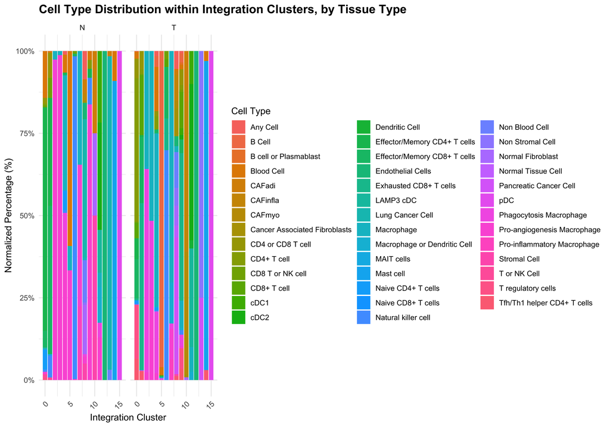

```r
# Rename the final calculated table for clarity
dt_plot_data <- dt_normalized_tissue

# --- 1. Generate the Plot (Assign to variable) ---
plot_final_revision <- ggplot(dt_plot_data,
       aes(x = integration_cluster,
           y = percentage,
           fill = cell_type)) +

  # Stacked bar chart
  geom_bar(stat = "identity", position = "stack") +

  # Facet by Tissue Type (N/T)
  facet_wrap(~ sample_type) +

  # Labels and themes
  labs(title = "Cell Type Distribution within Integration Clusters, by Tissue Type",
       y = "Normalized Percentage (%)",
       x = "Integration Cluster",
       fill = "Cell Type") +

  theme_minimal() +
  theme(axis.text.x = element_text(angle = 45, hjust = 1),
        plot.title = element_text(face = "bold", size = 14)) +

  # Ensure Y-axis is formatted correctly
  scale_y_continuous(labels = scales::percent_format(scale = 1))

# --- 2. Save the Plot (PNG file) ---
# Saves the graph in high resolution (300dpi) to the working directory
ggsave(filename = file.path(output_dir, "FinalTask_CellTypeDistribution.png"),
       plot = plot_final_revision,
       width = 10,
       height = 6,
       units = "in",
       dpi = 300)

# --- 3. Print the Plot (for embedding in the HTML/PDF report) ---
print(plot_final_revision)
```

# Final Performance Results

Finally, we print the complete cumulative performance table. All tasks have been executed, and the timings are correctly aligned in their respective columns, providing a direct comparison of `data.table`, `data.frame`, and `SQL` efficiency across all project tasks.

```r
cat("--- FINAL CUMULATIVE PERFORMANCE TABLE ---\n")
```

```
## --- FINAL CUMULATIVE PERFORMANCE TABLE ---
```

```r
# Print the final table in the report
print(performance_comparison)
```

```
##                                    Task Time_DataFrame (s) Time_DataTable (s)
##                                  <char>              <num>              <num>
##  1:             T1.1 Filter & Summarize              0.008              0.002
##  2:               T1.2 Join & Summarize              0.005              0.002
##  3:              T2.1 Log2 & Fixed Flag              0.001              0.001
##  4:         T2.2 Overwrite Flag by Gene              0.008              0.007
##  5:              T3.1 Equi-Join (Keyed)              0.001                 NA
##  6:     T3.2 Lookup (Index vs No-Index)                 NA                 NA
##  7:       T4.1 Total Counts per Patient              0.002              0.001
##  8:      T4.2 Top 10 Genes by Condition              0.022              0.002
##  9:            T5.1 Non-Equi Join Label              0.003              0.001
## 10:       T5.2 Summarize Abnormal Rates              0.002              0.001
## 11:                   T6.1 Rolling Join                 NA                 NA
## 12:          T6.2 Summarize Correlation              0.004              0.002
## 13:          T7.1 Filter Genomic Region              0.001              0.001
```

[output cut: 72 more lines]

```r
cat("\n*** TOTAL ANALYSIS COMPLETED ***\n")
```

```
##
## *** TOTAL ANALYSIS COMPLETED ***
```

# Discussion and Conclusion

## Alternative Packages and Methods

The project specified comparing `data.table` with conventional `data.frame` R structure and suggested other packages. We incorporated `dplyr` (representing the tidyverse ecosystem) and `sqldf` (representing SQL database operations) in this comparison.